# Group Modeling: PBS Utah Major Donor Prediction

```python
# where each ordering's 1,000 places go, by prior-year giving band (average places a year)
mix_parts = []
for name, col in EXP_SCORES.items():
    d = with_list_share(amounts_test, col, "on_list")
    mix_parts.append(d.group_by("band").agg(pl.col("on_list").sum() / len(TEST_COHORTS)).rename({"on_list": name}))
mix = mix_parts[0]
for part in mix_parts[1:]:
    mix = mix.join(part, on="band", how="full", coalesce=True)
mix = mix.sort("band").fill_null(0.0)
eligible_mix = amounts_test.group_by("band").agg(eligible_donors=pl.len() / len(TEST_COHORTS), converters=yf.sum() / len(TEST_COHORTS),
                                                 mean_probability=pl.col("model_score").mean(), rolling_expected_giving=pl.col("expected_giving").mean()).sort("band")
mix = eligible_mix.join(mix, on="band", how="left")
mx = {r["band"]: r for r in mix.iter_rows(named=True)}
show(mix, pct_cols=["mean_probability"], pct_digits=2, fixed={c: 0 for c in mix.columns if c not in ("band", "mean_probability")},
     caption="Eligible donors, converters, the model's mean probability, the rolling expected giving, and list places by prior-year giving band, averaged over FY2022 to FY2024")
```

Table 45: Eligible donors, converters, the model's mean probability, the rolling expected giving, and list places by prior-year giving band, averaged over FY2022 to FY2024

| Band | Eligible donors | Converters | Mean probability | Rolling expected giving | Model probability | Expected increase | Expected total | Officer rule | Prior-year giving |
| --- | --- | --- | --- | --- | --- | --- | --- | --- | --- |
| under $100 | 22,597 | 5 | 0.03% | 1,478 | 47 | 58 | 44 | 60 | 0 |
| $100 to $249 | 7,814 | 1 | 0.03% | 1,508 | 7 | 7 | 7 | 10 | 0 |
| $250 to $599 | 1,718 | 9 | 0.27% | 1,561 | 679 | 668 | 682 | 662 | 732 |
| $600 to $1,199 | 268 | 30 | 9.23% | 1,560 | 267 | 267 | 267 | 268 | 268 |

```python
inc, tot = "expected increase", "expected total"
conv_inc, conv_tot = ex[("converters", inc)], ex[("converters", tot)]
dol_inc, dol_tot = ex[("conversion-year dollars", inc)], ex[("conversion-year dollars", tot)]
rise_inc, rise_tot = ex[("increase over the prior year", inc)], ex[("increase over the prior year", tot)]
prob_dollars = ex[("conversion-year dollars", "model probability")]
rule_dollars = ex[("conversion-year dollars", "officer rule")]
top_band, low_bands = mx["$600 to $1,199"], [mx[b] for b in BAND_NAMES[:3]]
bt = {r["band"]: r for r in band_table.iter_rows(named=True)}
inc_900 = top_band["rolling_expected_giving"] - 900
inc_300 = mx["$250 to $599"]["rolling_expected_giving"] - 300
prob_ratio = top_band["mean_probability"] / max(b["mean_probability"] for b in low_bands)
assert inc_300 > inc_900 and prob_ratio > 10            # on the test cohorts the amount favoured lower givers; the probability gap dwarfed it
assert bt["$600 to $1,199"]["expected_giving"] > max(bt[b]["expected_giving"] for b in BAND_NAMES[:3])   # by FY2025 it points the other way
assert min(conv_inc["places_shared_with_probability"], conv_tot["places_shared_with_probability"]) > 0.95
assert all(ex[(m, r)]["gain_high"] <= 1e-9 for m in MEASURES for r in (inc, tot))   # never ahead of the probability ranking
"expected giving claims hold"
```

```
'expected giving claims hold'
```

On this release, then, ranking by expected giving changes the list by a few names and the dollars by nothing measurable, which is what our instructor expected. The value is in the method: the list now carries a probability, an expected amount, and their product for every donor, so on PBS Utah’s own records, where the dollar level may be more predictable than it is here, the same code produces the expected-dollar ordering and the same test says whether it earns its place. The list-size curves below put each ordering in dollars per name.

### 9.3 The List-Size Curve (D26)

Every table so far scores a list of 1,000, a size taken from the cultivation program’s capacity in tables that were invented for this release. The amendment turns the list size into an output. For each ranking, the curve below accumulates what the list holds as it grows, name by name: converters a year and conversion-year dollars a year on the test cohorts, with the couple-clustered band for the model and a paired band for the model’s difference from the officer rule. The marginal version shows what the next 250 names add, which is the number a development director would set against the cost of working them. The same curves are drawn for the pre-program cohorts, where simulated contact played no part.

```python
SIZES = list(range(50, 5001, 50))
CURVE_SCORES = {"model probability": "model_score", "officer rule": "rule_officer", "prior-year giving": "prior_total"}

def hits_by_size(y, w, gid, sizes):
    # weighted y on the top-k list for every k at once; the tied group at each cutoff is split evenly, as in share_on_list
    gw, gy = np.bincount(gid, weights=w), np.bincount(gid, weights=w * y)
    cum_w, cum_y = np.cumsum(gw), np.cumsum(gy)
    k = np.asarray(sizes, dtype=float)
    g = np.minimum(np.searchsorted(cum_w, k), len(gw) - 1)
    before_w = np.where(g > 0, cum_w[g - 1], 0.0)
    before_y = np.where(g > 0, cum_y[g - 1], 0.0)
    return before_y + np.clip((k - before_w) / gw[g], 0, 1) * gy[g]

def curves(df, scores, ycol, sizes=SIZES, reps=REPS, seed=SEED):
    """Per-year total of ycol on each ranking's top-k list for every k in sizes, with bootstrap draws for paired comparisons."""
    d = df.with_columns(y=pl.col(ycol).cast(pl.Float64))
    couples = d["couple_id"].unique().sort()
    lists = {name: [(couples.search_sorted(c).to_numpy(), y, w, gid) for c, y, w, gid in ranked(d, col)] for name, col in scores.items()}
    years = d["t"].n_unique()

    def totals(mult):
        return {name: sum(hits_by_size(y, w if mult is None else w * mult[idx], gid, sizes) for idx, y, w, gid in parts) / years
                for name, parts in lists.items()}

    point = totals(None)
    rng = np.random.default_rng(seed)
    draws = {name: np.empty((reps, len(sizes))) for name in scores}
    for r in range(reps):
        mult = np.bincount(rng.integers(0, len(couples), len(couples)), minlength=len(couples)).astype(float)
        for name, v in totals(mult).items():
            draws[name][r] = v
    rows = []
    for name in scores:
        lo, hi = np.quantile(draws[name], [0.025, 0.975], axis=0)
        rows += [{"ranking": name, "list_size": k, "per_year": point[name][i], "low": lo[i], "high": hi[i]} for i, k in enumerate(sizes)]
    return pl.DataFrame(rows), point, draws

# the vectorised cutoff agrees with the scoring used everywhere else
chk = amounts_test.filter(pl.col("t") == TEST_COHORTS[0])
(_, y_, w_, gid_), = ranked(chk, "model_score")
assert np.isclose(hits_by_size(y_, w_, gid_, [K])[0], (share_on_list(w_, gid_, K) * w_ * y_).sum())

pre_df = (scored.filter(pl.col("t").is_in(PRE_PROGRAM)).join(pre_run[0].rename({"score": "model_score"}), on=["constituent_id", "t"], how="left")
          .join(converters.select("constituent_id", "t", "conversion_total"), on=["constituent_id", "t"], how="left")
          .with_columns(conversion_total=pl.col("conversion_total").fill_null(0.0)))
assert pre_df["model_score"].null_count() == 0
CURVE_SETS = {"FY2022 to FY2024 test cohorts": amounts_test, "FY2018 to FY2021, before the program": pre_df}
CURVE_MEASURES = {"converters a year": "y", "conversion-year dollars a year": "conversion_total"}
curve_tables, curve_points, curve_draws = {}, {}, {}
for s, df in CURVE_SETS.items():
    for m, ycol in CURVE_MEASURES.items():
        curve_tables[(s, m)], curve_points[(s, m)], curve_draws[(s, m)] = curves(df, CURVE_SCORES, ycol)
```

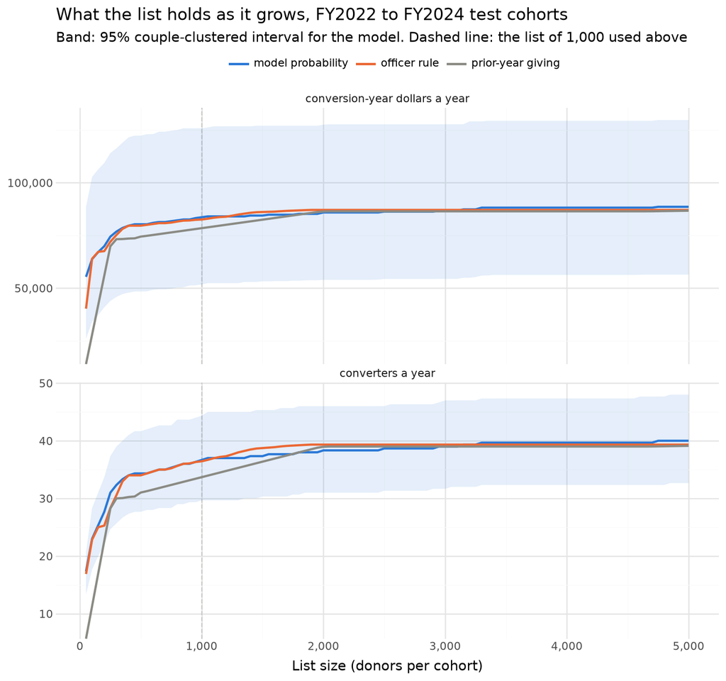

```python
def curve_frame(s):
    return pl.concat([tbl.with_columns(measure=pl.lit(m)) for (ss, m), tbl in curve_tables.items() if ss == s]).to_pandas()

CURVE_COLORS = {"model probability": "#2a78d6", "officer rule": "#eb6834", "prior-year giving": "#8b8b84"}

def curve_plot(s):
    cf = curve_frame(s)
    band = cf[cf["ranking"] == "model probability"]
    return (
        ggplot(cf, aes("list_size", "per_year", color="ranking"))
        + geom_vline(xintercept=1000, color="#c9c8c3", linetype="dashed")
        + geom_ribbon(aes(ymin="low", ymax="high"), data=band, fill="#2a78d6", alpha=0.12, color="none")
        + geom_line(size=1)
        + facet_wrap("measure", ncol=1, scales="free_y")
        + scale_color_manual(values=CURVE_COLORS)
        + scale_x_continuous(breaks=[0, 1000, 2000, 3000, 4000, 5000], labels=lambda xs: [f"{x:,.0f}" for x in xs])
        + scale_y_continuous(labels=lambda ys: [f"{y:,.0f}" for y in ys], expand=(0, 0, 0.05, 0))
        + labs(x="List size (donors per cohort)", y="", color="", title=f"What the list holds as it grows, {s}",
               subtitle="Band: 95% couple-clustered interval for the model. Dashed line: the list of 1,000 used above")
        + theme(legend_position="top", figure_size=(8, 7.5))
    )

curve_plot("FY2022 to FY2024 test cohorts")
```

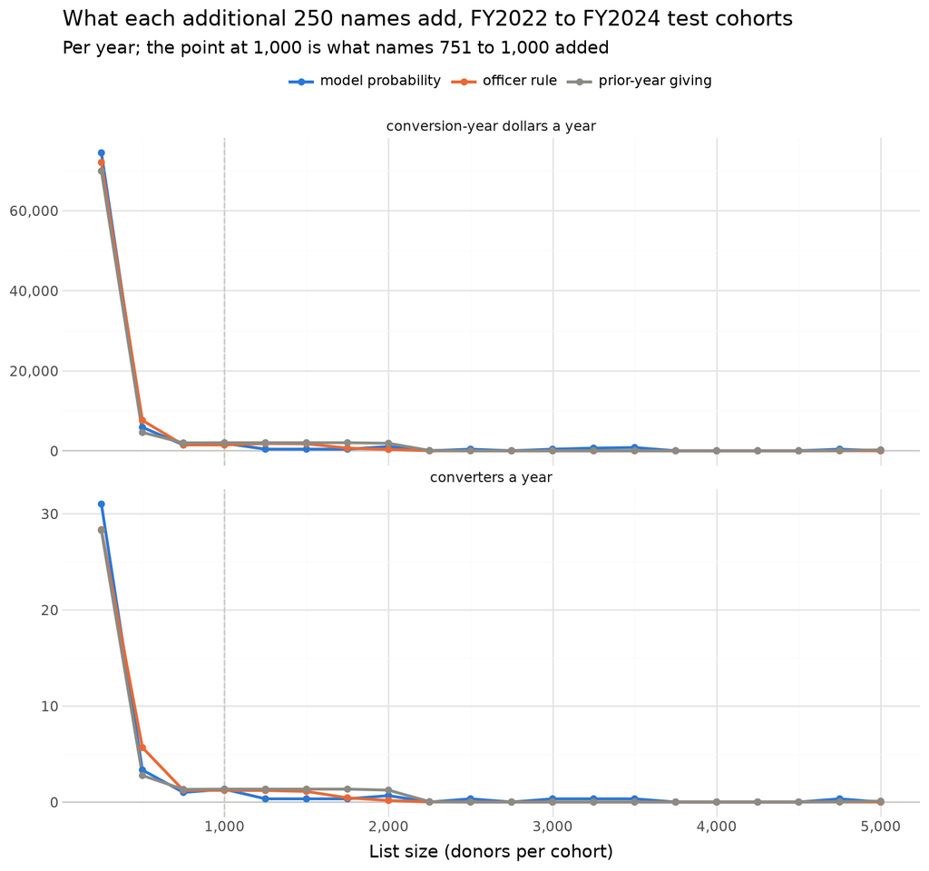

```python
STEP = 250
def marginal_frame(s):
    rows = []
    for (ss, m), point in curve_points.items():
        if ss != s:
            continue
        idx = [SIZES.index(k) for k in range(STEP, 5001, STEP)]
        for name, v in point.items():
            prev = 0.0
            for i in idx:
                rows.append({"measure": m, "ranking": name, "list_size": SIZES[i], "added": v[i] - prev})
                prev = v[i]
    return pl.DataFrame(rows)

marg_test = marginal_frame("FY2022 to FY2024 test cohorts")
(
    ggplot(marg_test.to_pandas(), aes("list_size", "added", color="ranking"))
    + geom_vline(xintercept=1000, color="#c9c8c3", linetype="dashed")
    + geom_hline(yintercept=0, color="#c9c8c3")
    + geom_line(size=1)
    + geom_point(size=1.5)
    + facet_wrap("measure", ncol=1, scales="free_y")
    + scale_color_manual(values=CURVE_COLORS)
    + scale_x_continuous(breaks=[0, 1000, 2000, 3000, 4000, 5000], labels=lambda xs: [f"{x:,.0f}" for x in xs])
    + scale_y_continuous(labels=lambda ys: [f"{y:,.0f}" for y in ys])
    + labs(x="List size (donors per cohort)", y="", color="", title="What each additional 250 names add, FY2022 to FY2024 test cohorts",
           subtitle="Per year; the point at 1,000 is what names 751 to 1,000 added")
    + theme(legend_position="top", figure_size=(8, 7.5))
)
```

```python
SHOW_SIZES = [250, 500, 1000, 1500, 2000, 3000, 5000]
def size_table(s):
    rows = []
    for k in SHOW_SIZES:
        i = SIZES.index(k)
        row = {"list_size": k}
        for m, short in (("converters a year", "converters"), ("conversion-year dollars a year", "dollars")):
            p = curve_points[(s, m)]
            diff = curve_draws[(s, m)]["model probability"][:, i] - curve_draws[(s, m)]["officer rule"][:, i]
            row.update({f"{short}_model": p["model probability"][i], f"{short}_officer_rule": p["officer rule"][i],
                        f"{short}_prior_year": p["prior-year giving"][i], f"{short}_model_minus_rule": p["model probability"][i] - p["officer rule"][i],
                        f"{short}_diff_low": float(np.quantile(diff, 0.025)), f"{short}_diff_high": float(np.quantile(diff, 0.975))})
        rows.append(row)
    return pl.DataFrame(rows)

size_test = size_table("FY2022 to FY2024 test cohorts")
size_pre = size_table("FY2018 to FY2021, before the program")
st = {r["list_size"]: r for r in size_test.iter_rows(named=True)}
sp = {r["list_size"]: r for r in size_pre.iter_rows(named=True)}
conv_cols = [c for c in size_test.columns if c.startswith("converters")]
dol_cols = [c for c in size_test.columns if c.startswith("dollars")]
show(size_test.select("list_size", *conv_cols), fixed={c: 1 for c in conv_cols},
     caption="Converters a year on each ranking's list by list size, FY2022 to FY2024, with the paired difference between the model and the officer rule")
```

Table 46: Converters a year on each ranking's list by list size, FY2022 to FY2024, with the paired difference between the model and the officer rule

| List size | Converters model | Converters officer rule | Converters prior year | Converters model minus rule | Converters diff low | Converters diff high |
| --- | --- | --- | --- | --- | --- | --- |
| 250 | 31.0 | 28.3 | 28.3 | 2.7 | -0.5 | 6.2 |
| 500 | 34.3 | 34.0 | 31.0 | 0.3 | -0.7 | 1.3 |
| 1,000 | 36.7 | 36.4 | 33.7 | 0.2 | -1.8 | 2.3 |
| 1,500 | 37.3 | 38.7 | 36.4 | -1.4 | -2.7 | -0.1 |
| 2,000 | 38.3 | 39.3 | 39.0 | -1.0 | -2.3 | 0.0 |
| 3,000 | 39.0 | 39.3 | 39.0 | -0.3 | -1.3 | 0.0 |
| 5,000 | 40.0 | 39.3 | 39.1 | 0.7 | 0.0 | 1.7 |

```python
show(size_test.select("list_size", *dol_cols), fixed={c: 0 for c in dol_cols},
     caption="Conversion-year dollars a year on each ranking's list by list size, FY2022 to FY2024, with the paired difference between the model and the officer rule")
```

Table 47: Conversion-year dollars a year on each ranking's list by list size, FY2022 to FY2024, with the paired difference between the model and the officer rule

| List size | Dollars model | Dollars officer rule | Dollars prior year | Dollars model minus rule | Dollars diff low | Dollars diff high |
| --- | --- | --- | --- | --- | --- | --- |
| 250 | 74,418 | 72,018 | 69,871 | 2,400 | -2,179 | 7,668 |
| 500 | 80,284 | 79,618 | 74,442 | 667 | -1,333 | 2,682 |
| 1,000 | 83,618 | 82,537 | 78,431 | 1,081 | -1,891 | 4,309 |
| 1,500 | 84,418 | 86,099 | 82,459 | -1,681 | -3,282 | -105 |
| 2,000 | 85,884 | 87,084 | 86,347 | -1,200 | -3,067 | 0 |
| 3,000 | 86,684 | 87,084 | 86,418 | -400 | -1,600 | 0 |
| 5,000 | 88,565 | 87,084 | 86,713 | 1,480 | 0 | 3,774 |

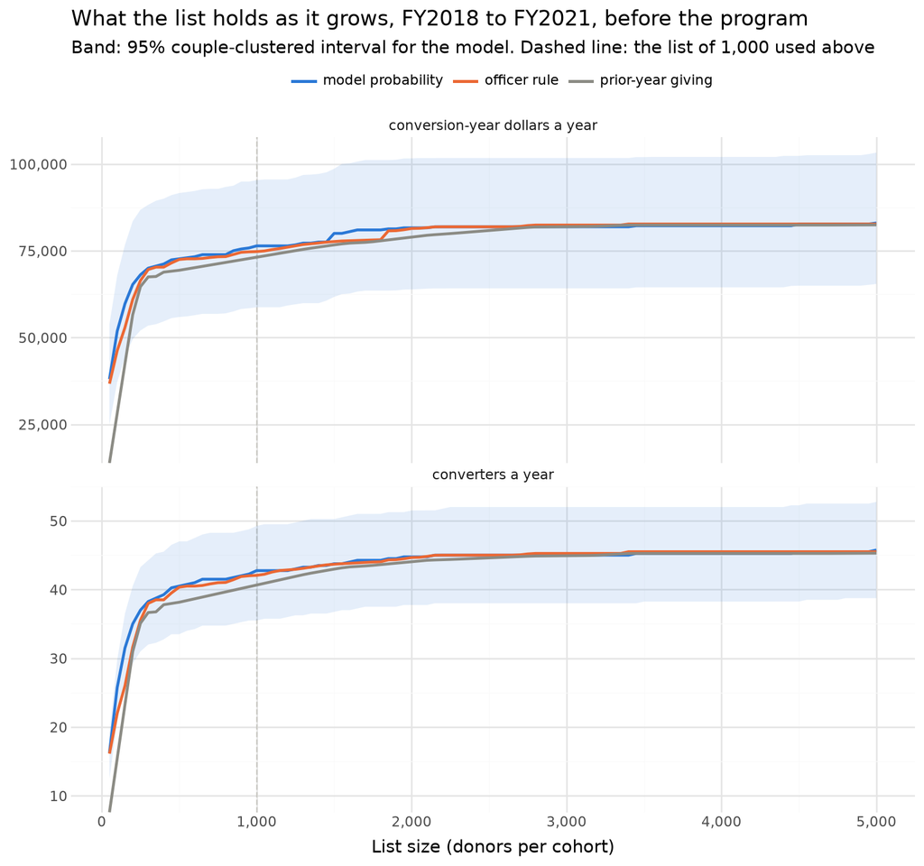

```python
curve_plot("FY2018 to FY2021, before the program")
```

```python
show(size_pre.select("list_size", *conv_cols), fixed={c: 1 for c in conv_cols},
     caption="Converters a year by list size on the FY2018 to FY2021 cohorts, before the cultivation program")
```

Table 48: Converters a year by list size on the FY2018 to FY2021 cohorts, before the cultivation program

| List size | Converters model | Converters officer rule | Converters prior year | Converters model minus rule | Converters diff low | Converters diff high |
| --- | --- | --- | --- | --- | --- | --- |
| 250 | 37.0 | 35.5 | 35.1 | 1.5 | -0.3 | 4.5 |
| 500 | 40.5 | 40.3 | 38.2 | 0.2 | -1.0 | 1.5 |
| 1,000 | 42.8 | 42.1 | 40.7 | 0.7 | -0.8 | 1.7 |
| 1,500 | 43.8 | 43.7 | 43.0 | 0.1 | -1.0 | 1.1 |
| 2,000 | 44.8 | 44.7 | 44.0 | 0.1 | -0.5 | 0.9 |
| 3,000 | 45.0 | 45.2 | 44.9 | -0.2 | -0.8 | 0.0 |
| 5,000 | 45.8 | 45.5 | 45.3 | 0.2 | -0.8 | 1.5 |

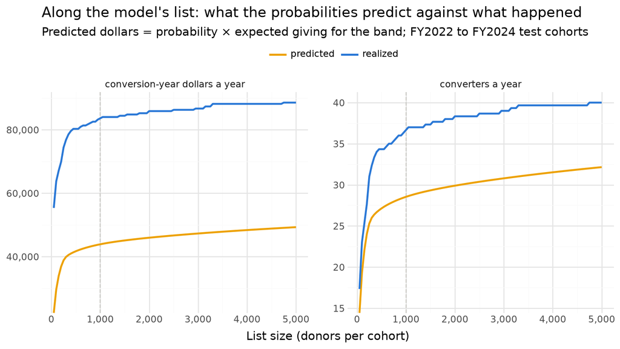

```python
# along the model's own list: dollars the probabilities predict against dollars the converters gave
pred_tbl, pred_pt, _ = curves(amounts_test.with_columns(predicted_dollars=pl.col("model_score") * pl.col("expected_giving")),
                              {"model probability": "model_score"}, "predicted_dollars", reps=1)
real_pt = curve_points[("FY2022 to FY2024 test cohorts", "conversion-year dollars a year")]["model probability"]
pred_conv_tbl, pred_conv_pt, _ = curves(amounts_test, {"model probability": "model_score"}, "model_score", reps=1)
real_conv = curve_points[("FY2022 to FY2024 test cohorts", "converters a year")]["model probability"]
ev = pl.concat([
    pl.DataFrame({"list_size": SIZES, "per_year": real_pt, "series": "realized", "measure": "conversion-year dollars a year"}),
    pl.DataFrame({"list_size": SIZES, "per_year": pred_pt["model probability"], "series": "predicted", "measure": "conversion-year dollars a year"}),
    pl.DataFrame({"list_size": SIZES, "per_year": real_conv, "series": "realized", "measure": "converters a year"}),
    pl.DataFrame({"list_size": SIZES, "per_year": pred_conv_pt["model probability"], "series": "predicted", "measure": "converters a year"}),
])
i1000 = SIZES.index(1000)
pred_ratio_1000 = pred_pt["model probability"][i1000] / real_pt[i1000]
(
    ggplot(ev.to_pandas(), aes("list_size", "per_year", color="series"))
    + geom_vline(xintercept=1000, color="#c9c8c3", linetype="dashed")
    + geom_line(size=1)
    + facet_wrap("measure", scales="free_y")
    + scale_color_manual(values={"realized": "#2a78d6", "predicted": "#eda100"})
    + scale_x_continuous(breaks=[0, 1000, 2000, 3000, 4000, 5000], labels=lambda xs: [f"{x:,.0f}" for x in xs])
    + scale_y_continuous(labels=lambda ys: [f"{y:,.0f}" for y in ys], expand=(0, 0, 0.05, 0))
    + labs(x="List size (donors per cohort)", y="", color="", title="Along the model's list: what the probabilities predict against what happened",
           subtitle="Predicted dollars = probability × expected giving for the band; FY2022 to FY2024 test cohorts")
    + theme(legend_position="top", figure_size=(8, 4.5))
)
```

```python
def flat_after(point, name, floor):
    # first list size after which no later 250-name block adds more than floor
    for k in range(STEP, 5001, STEP):
        if all(point[name][SIZES.index(j)] - point[name][SIZES.index(j - STEP)] <= floor for j in range(k + STEP, 5001, STEP)):
            return k
    return 5000

conv_pt = curve_points[("FY2022 to FY2024 test cohorts", "converters a year")]
dol_pt = curve_points[("FY2022 to FY2024 test cohorts", "conversion-year dollars a year")]
pre_conv_pt = curve_points[("FY2018 to FY2021, before the program", "converters a year")]
total_conv = float(amounts_test["y"].cast(pl.Float64).sum()) / len(TEST_COHORTS)
total_dol = float(amounts_test["conversion_total"].sum()) / len(TEST_COHORTS)
pre_total_conv = float(pre_df["y"].cast(pl.Float64).sum()) / len(PRE_PROGRAM)

def at(point, name, k):
    return point[name][SIZES.index(k)]

def added(point, name, k, step=STEP):
    return at(point, name, k) - at(point, name, k - step)

M, R, P = "model probability", "officer rule", "prior-year giving"
conv_excl = [k for k in SHOW_SIZES if st[k]["converters_diff_low"] > 0 or st[k]["converters_diff_high"] < 0]
dol_excl = [k for k in SHOW_SIZES if st[k]["dollars_diff_low"] > 0 or st[k]["dollars_diff_high"] < 0]
spread_2000 = max(at(conv_pt, n, 2000) for n in CURVE_SCORES) - min(at(conv_pt, n, 2000) for n in CURVE_SCORES)
assert at(conv_pt, M, 250) / at(conv_pt, M, 1000) > 0.8 and at(dol_pt, M, 250) / at(dol_pt, M, 1000) > 0.8   # most of the list's return is in the first 250
assert added(conv_pt, M, 1000) < 2 and added(dol_pt, M, 1000) < 3000                                         # names 751 to 1,000 add little
assert spread_2000 < 1.5                                                                                     # by 2,000 the rankings converge
assert 0.4 < pred_ratio_1000 < 0.7
"list size claims hold"
```

```
'list size claims hold'
```

- **Most of the return is in the first few hundred names.** On the test cohorts the model’s first 250 names hold 31.0 converters a year, 85% of what the list of 1,000 holds, and $74,418 of conversion-year giving, 89% of the list of 1,000’s $83,618. Names 251 to 500 add 3.3 converters and $5,867; names 501 to 750 add 1.0 and $1,467; names 751 to 1,000 add 1.3 and $1,867. The officer rule’s curve has the same shape, 28.3 converters in its first 250 and 36.4 at 1,000.
- **By about 2,000 names the ranking stops mattering.** The three curves meet there, within 1.0 converters a year of each other, because by then every list holds every donor who gave $250 or more. Prior-year giving gets there last: it has 28.3 converters in its first 250 and 33.7 at 1,000, and catches up only as it works through the $250 block. Beyond 2,000, the 6.3 remaining converters a year, out of 44.7, are spread through tens of thousands of low givers that no ranking finds.
- **Model against rule along the whole curve.** The paired difference between the model and the officer rule stays within about two converters a year at every size. The only size in the table where its interval excludes zero is 1,500 names; at 1,500 the rule is ahead by 1.4 converters (0.1 to 2.7) and $1,681, where its tie-break by years of giving orders the $250 block better than the model does. The tie at 1,000 is a tie everywhere that matters.
- **Before the program, the same shape.** On the FY2018 to FY2021 cohorts the model’s first 250 names hold 37.0 of 49.2 converters a year, 1,000 names 42.8, and 2,000 names 44.8. Names 501 to 1,000 add 2.2 converters a year, against 2.3 on the test cohorts, so the place where the curve flattens is the same with and without simulated contact. The model’s lead over the officer rule at 1,000 is 0.7 converters (-0.8 to 1.7), again a tie.
- **What the probabilities predict runs below what happened.** Along the model’s list, the probabilities times the band’s expected giving add up to 52% of the conversion-year dollars the first 1,000 names actually produced, and predicted converters run below realized converters at every size. The shortfall is the calibration result from the Model Performance section, now in dollars, and it means the curve PBS Utah plans from should be the backtest curve, with the predicted curve as a floor.

### 9.4 The Retention Curve (D27)

The same curve is drawn for stewardship. Each year’s major donors are ranked, and the curve accumulates two things as the list grows: how many of the donors on it fell below $1,200 the next year, and how much giving the donors on it actually lost the next year. Five rankings are compared. Two are the ones R6 tested, the model’s drop probability and lowest givers first; one is the first-time rule from D24; and two are dollars at risk, a probability times the donor’s giving. The model’s dollars at risk uses the model’s probability. The rule’s uses a lookup table an officer could keep: the drop rate of first-time and repeat major donors in the cohorts before the one being scored. If the lookup table ranks dollars as well as the model does, the model has no remaining job in retention.

```python
RET_SIZES = list(range(5, 101, 5))
share_lost = float((retention.filter(pl.col("y_drop"))["decline"] / retention.filter(pl.col("y_drop"))["prior_total"]).mean())

def tenure_rates(last_cohort):
    # drop rate of first-time and repeat major donors, from MAIN_START through last_cohort
    d = retention.filter(pl.col("t").is_between(MAIN_START, last_cohort)).with_columns(first_time=pl.col("major_years_before") == 0)
    return d.group_by("first_time").agg(tenure_rate=pl.col("y_drop").mean())

def with_risk_scores(df, last_cohort):
    d = df.with_columns(first_time=pl.col("major_years_before") == 0).join(tenure_rates(last_cohort), on="first_time", how="left")
    assert d["tenure_rate"].null_count() == 0
    return d.with_columns(model_dollars=pl.col("model") * share_lost * pl.col("prior_total"),
                          rule_dollars=pl.col("tenure_rate") * share_lost * pl.col("prior_total"))

ret_test = pl.concat([with_risk_scores(retention_frame(retention_run, [T]), T - 1) for T in TEST_COHORTS])
ret_2025 = with_risk_scores(retention_frame(retention_check, [2025]), 2024)
RET_CURVE_SCORES = {"model probability": "model", "model dollars at risk": "model_dollars", "rule dollars at risk (tenure table)": "rule_dollars",
                    RET_RULE: "first_time_rule", "lowest giving first": "lowest_first"}
RET_MEASURES = {"donors who dropped, a year": "y", "next-year giving lost, a year": "decline"}
ret_curve_tables, ret_curve_points, ret_curve_draws = {}, {}, {}
for m, ycol in RET_MEASURES.items():
    ret_curve_tables[m], ret_curve_points[m], ret_curve_draws[m] = curves(ret_test, RET_CURVE_SCORES, ycol, sizes=RET_SIZES)
chk_points = {m: curves(ret_2025, RET_CURVE_SCORES, ycol, sizes=RET_SIZES, reps=1)[1] for m, ycol in RET_MEASURES.items()}
tr = {bool(r["first_time"]): r["tenure_rate"] for r in tenure_rates(2025).iter_rows(named=True)}
```

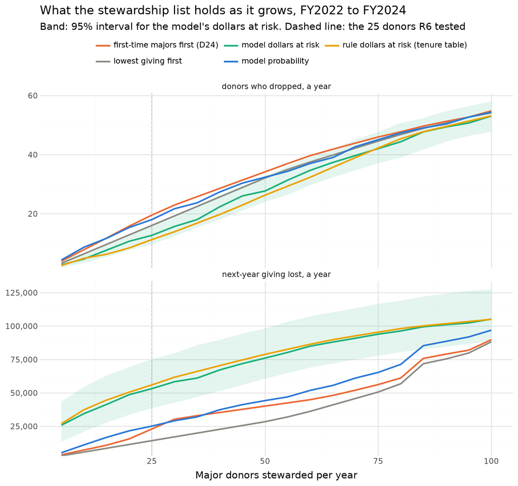

```python
RET_COLORS = {"model probability": "#2a78d6", "model dollars at risk": "#1baf7a", "rule dollars at risk (tenure table)": "#eda100",
              RET_RULE: "#eb6834", "lowest giving first": "#8b8b84"}
rcf = pl.concat([tbl.with_columns(measure=pl.lit(m)) for m, tbl in ret_curve_tables.items()]).to_pandas()
rband = rcf[rcf["ranking"] == "model dollars at risk"]
(
    ggplot(rcf, aes("list_size", "per_year", color="ranking"))
    + geom_vline(xintercept=25, color="#c9c8c3", linetype="dashed")
    + geom_ribbon(aes(ymin="low", ymax="high"), data=rband, fill="#1baf7a", alpha=0.12, color="none")
    + geom_line(size=1)
    + facet_wrap("measure", ncol=1, scales="free_y")
    + scale_color_manual(values=RET_COLORS)
    + scale_x_continuous(breaks=[0, 25, 50, 75, 100])
    + scale_y_continuous(labels=lambda ys: [f"{y:,.0f}" for y in ys], expand=(0, 0, 0.05, 0))
    + labs(x="Major donors stewarded per year", y="", color="", title="What the stewardship list holds as it grows, FY2022 to FY2024",
           subtitle="Band: 95% interval for the model's dollars at risk. Dashed line: the 25 donors R6 tested")
    + theme(legend_position="top", figure_size=(8, 7.5))
    + guides(color=guide_legend(nrow=2))
)
```

```python
RET_SHOW = [10, 25, 50, 75, 100]
MD, RD, FT, LF = "model dollars at risk", "rule dollars at risk (tenure table)", RET_RULE, "lowest giving first"
def ret_size_table(points, draws=None):
    rows = []
    for k in RET_SHOW:
        i = RET_SIZES.index(k)
        row = {"list_size": k}
        for m, short in (("donors who dropped, a year", "droppers"), ("next-year giving lost, a year", "dollars")):
            p = points[m]
            row.update({f"{short}_model_dollars": p[MD][i], f"{short}_rule_dollars": p[RD][i], f"{short}_first_time_rule": p[FT][i],
                        f"{short}_lowest_first": p[LF][i], f"{short}_model_probability": p["model probability"][i]})
            if draws is not None:
                d1 = draws[m][MD][:, i] - draws[m][RD][:, i]
                row.update({f"{short}_model_minus_rule_dollars": p[MD][i] - p[RD][i],
                            f"{short}_diff_low": float(np.quantile(d1, 0.025)), f"{short}_diff_high": float(np.quantile(d1, 0.975))})
        rows.append(row)
    return pl.DataFrame(rows)

ret_size = ret_size_table(ret_curve_points, ret_curve_draws)
ret_size_2025 = ret_size_table(chk_points)
rs = {r["list_size"]: r for r in ret_size.iter_rows(named=True)}
rs25 = {r["list_size"]: r for r in ret_size_2025.iter_rows(named=True)}
drop_cols = [c for c in ret_size.columns if c.startswith("droppers")]
lost_cols = [c for c in ret_size.columns if c.startswith("dollars")]
show(ret_size.select("list_size", *drop_cols), fixed={c: 1 for c in drop_cols},
     caption="Major donors who dropped, found by each ranking's list by list size, FY2022 to FY2024, with the paired difference between the model's and the rule's dollars at risk")
```

Table 49: Major donors who dropped, found by each ranking's list by list size, FY2022 to FY2024, with the paired difference between the model's and the rule's dollars at risk

| List size | Droppers model dollars | Droppers rule dollars | Droppers first time rule | Droppers lowest first | Droppers model probability | Droppers model minus rule dollars | Droppers diff low | Droppers diff high |
| --- | --- | --- | --- | --- | --- | --- | --- | --- |
| 10 | 4.7 | 4.9 | 7.8 | 6.4 | 8.7 | -0.2 | -1.1 | 1.9 |
| 25 | 12.7 | 11.2 | 19.5 | 16.0 | 18.0 | 1.4 | -0.2 | 3.6 |
| 50 | 27.7 | 26.3 | 34.1 | 32.1 | 32.3 | 1.4 | -0.2 | 5.0 |
| 75 | 42.0 | 42.2 | 45.9 | 44.5 | 45.0 | -0.2 | -1.7 | 2.5 |
| 100 | 53.0 | 53.1 | 54.8 | 54.1 | 54.3 | -0.1 | -1.5 | 1.3 |

```python
show(ret_size.select("list_size", *lost_cols), fixed={c: 0 for c in lost_cols},
     caption="Next-year giving lost by the donors on each ranking's list by list size, FY2022 to FY2024, with the paired difference between the model's and the rule's dollars at risk")
```

Table 50: Next-year giving lost by the donors on each ranking's list by list size, FY2022 to FY2024, with the paired difference between the model's and the rule's dollars at risk

| List size | Dollars model dollars | Dollars rule dollars | Dollars first time rule | Dollars lowest first | Dollars model probability | Dollars model minus rule dollars | Dollars diff low | Dollars diff high |
| --- | --- | --- | --- | --- | --- | --- | --- | --- |
| 10 | 34,437 | 37,308 | 7,202 | 5,673 | 11,034 | -2,871 | -6,500 | 895 |
| 25 | 53,119 | 55,933 | 22,947 | 14,181 | 25,085 | -2,814 | -7,389 | 996 |
| 50 | 75,966 | 78,778 | 40,052 | 28,363 | 44,165 | -2,812 | -6,816 | 1,547 |
| 75 | 93,888 | 95,377 | 56,158 | 50,583 | 65,260 | -1,489 | -3,687 | 742 |
| 100 | 105,137 | 104,983 | 89,715 | 88,174 | 96,854 | 154 | -1,568 | 913 |

```python
show(ret_size_2025.select("list_size", *[c for c in ret_size_2025.columns if c.startswith("dollars")]), fixed={c: 0 for c in lost_cols if c in ret_size_2025.columns},
     caption="FY2025 check, scored once: next-year giving lost by the donors on each ranking's list")
```

Table 51: FY2025 check, scored once: next-year giving lost by the donors on each ranking's list

| List size | Dollars model dollars | Dollars rule dollars | Dollars first time rule | Dollars lowest first | Dollars model probability |
| --- | --- | --- | --- | --- | --- |
| 10 | 101,908 | 102,619 | 5,427 | 4,095 | 11,591 |
| 25 | 122,624 | 118,489 | 19,515 | 10,239 | 24,140 |
| 50 | 136,801 | 135,737 | 28,143 | 22,671 | 49,976 |
| 75 | 147,949 | 145,353 | 47,908 | 47,908 | 63,659 |
| 100 | 149,149 | 149,149 | 149,149 | 149,149 | 149,149 |

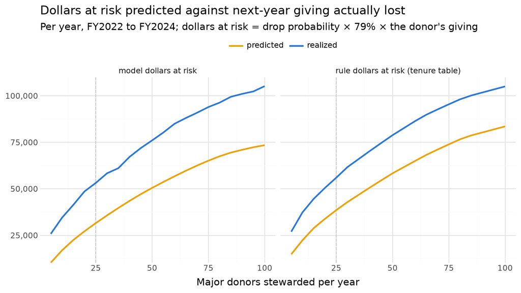

```python
pred_lost = curves(ret_test, {MD: "model_dollars"}, "model_dollars", sizes=RET_SIZES, reps=1)[1][MD]
pred_lost_rule = curves(ret_test, {RD: "rule_dollars"}, "rule_dollars", sizes=RET_SIZES, reps=1)[1][RD]
real_lost = ret_curve_points["next-year giving lost, a year"][MD]
real_lost_rule = ret_curve_points["next-year giving lost, a year"][RD]
rev = pl.concat([
    pl.DataFrame({"list_size": RET_SIZES, "per_year": real_lost, "series": "realized", "ranking": "model dollars at risk"}),
    pl.DataFrame({"list_size": RET_SIZES, "per_year": pred_lost, "series": "predicted", "ranking": "model dollars at risk"}),
    pl.DataFrame({"list_size": RET_SIZES, "per_year": real_lost_rule, "series": "realized", "ranking": "rule dollars at risk (tenure table)"}),
    pl.DataFrame({"list_size": RET_SIZES, "per_year": pred_lost_rule, "series": "predicted", "ranking": "rule dollars at risk (tenure table)"}),
])
i25 = RET_SIZES.index(25)
ret_pred_ratio_25 = pred_lost[i25] / real_lost[i25]
rule_pred_ratio_25 = pred_lost_rule[i25] / real_lost_rule[i25]
(
    ggplot(rev.to_pandas(), aes("list_size", "per_year", color="series"))
    + geom_vline(xintercept=25, color="#c9c8c3", linetype="dashed")
    + geom_line(size=1)
    + facet_wrap("ranking")
    + scale_color_manual(values={"realized": "#2a78d6", "predicted": "#eda100"})
    + scale_x_continuous(breaks=[0, 25, 50, 75, 100])
    + scale_y_continuous(labels=lambda ys: [f"{y:,.0f}" for y in ys], expand=(0, 0, 0.05, 0))
    + labs(x="Major donors stewarded per year", y="", color="", title="Dollars at risk predicted against next-year giving actually lost",
           subtitle="Per year, FY2022 to FY2024; dollars at risk = drop probability × 79% × the donor's giving")
    + theme(legend_position="top", figure_size=(8, 4.5))
)
```

```python
rdp, rlp = ret_curve_points["donors who dropped, a year"], ret_curve_points["next-year giving lost, a year"]
total_drop = float(ret_test["y"].cast(pl.Float64).sum()) / len(TEST_COHORTS)
total_lost = float(ret_test["decline"].sum()) / len(TEST_COHORTS)
def rat(point, name, k):
    return point[name][RET_SIZES.index(k)]
md_vs_rd_25 = paired({"point": {n: (rat(rlp, n, 25),) for n in RET_CURVE_SCORES},
                      "draws": {n: ret_curve_draws["next-year giving lost, a year"][n][:, [i25]] for n in RET_CURVE_SCORES}}, MD, RD)
dollar_excl = [k for k in RET_SHOW if rs[k]["dollars_diff_low"] > 0 or rs[k]["dollars_diff_high"] < 0]
drop_excl = [k for k in RET_SHOW if rs[k]["droppers_diff_low"] > 0 or rs[k]["droppers_diff_high"] < 0]
assert rat(rlp, MD, 25) > 1.8 * rat(rlp, FT, 25) and rat(rlp, RD, 25) > 1.8 * rat(rlp, FT, 25)   # dollars at risk covers about twice the lost giving
assert rat(rdp, FT, 25) > rat(rdp, MD, 25) + 5                                                   # and finds fewer of the donors who drop
assert md_vs_rd_25["low"] < 0 < md_vs_rd_25["high"] and not dollar_excl and not drop_excl         # model and tenure table cannot be told apart
assert 0.4 < ret_pred_ratio_25 < 0.8 and 0.4 < rule_pred_ratio_25 < 0.8
"retention curve claims hold"
```

```
'retention curve claims hold'
```

- **Ranking by dollars at risk covers about twice the lost giving.** Of the $107,953 a year that the test cohorts’ major donors gave less the next year, the 25 donors with the most dollars at risk by the model’s probability lost $53,119 and by the tenure table $55,933. The first-time rule’s 25 lost $22,947, the model’s probability ranking $25,085, and lowest givers first $14,181. The gap holds along the curve: at 50 donors the dollar rankings cover $78,778 against $40,052.
- **They find fewer of the donors who drop.** The same 25 by dollars at risk hold 12.7 (model) and 11.2 (tenure table) of the 56.3 donors a year who fell below $1,200, against 19.5 for the first-time rule. Dollars at risk points at the larger givers with a moderate chance of dropping; the first-time rule points at the donors at the $1,200 line who drop most often but have the least to lose. Which list to work is a choice about what stewardship is for, donors kept or dollars kept, and it belongs to PBS Utah.
- **The tenure table does the model’s job.** At 25 donors the lookup table’s list covered $2,814 more lost giving than the model’s, a difference whose 95% interval runs from 7,389 dollars in the table’s favour to 996 in the model’s, and the interval includes zero at every size in the table for dollars and for droppers. The table has two numbers in it: in FY2021 to FY2025, 78% of first-time major donors and 49% of repeat major donors fell below $1,200 the next year. On the FY2025 check the two rankings’ top 25 covered $122,624 and $118,489 of the $149,149 lost that year. With the first-time rule finding droppers as well as the model and the tenure table ranking dollars as well as the model, the retention model has nothing left that a rule does not do.
- **Predicted dollars at risk run below the dollars lost.** Along the model’s list, the dollars at risk add up to 59% of the giving the first 25 donors actually lost; along the table’s list, 69%. Dollars at risk are a ranking, not a forecast, and the backtest curve is the one to plan from.

Read together with the prospect curve, this gives a development director one chart in dollars for each list. On this release, the first 25 names on the stewardship list by dollars at risk hold about $55,933 a year of giving that was about to be lost, and the first 250 names on the prospect list hold about $72,018 a year of giving that was about to arrive. Neither is money a call will secure. What the two curves share is the unit, dollars per name worked, which is what the next section puts side by side.

### 9.5 The Next Call (D28)

The question an officer faces is not which list is better but which name to work next: the next prospect or the next at-risk major donor. The two curves above answer it once they are put in the same unit, dollars per name worked, block by block down each list. The prospect side is the officer rule’s list and the conversion-year giving of the converters on it; the retention side is the tenure table’s dollars-at-risk list and the giving its donors lost the next year. Both are backtest dollars, FY2022 to FY2024, and neither is money a call causes: in the backtest the prospects’ gifts arrived, and the major donors’ giving fell, with or without a call. What the chart shows is where the money concentrates, which is what decides the order of work. Because stewardship can only keep some share of the giving at risk, the retention side is also drawn at a 50% and a 25% save rate; the holdout test in the recommendations is how PBS Utah would learn the real number.

```python
PROSPECT_BLOCK, RETENTION_BLOCK = 50, 5
pros_cum = dol_pt[R]                     # officer rule, conversion-year dollars a year, by SIZES
ret_cum = rlp[RD]                        # tenure-table dollars at risk, next-year giving lost a year, by RET_SIZES

def per_name_blocks(cum, sizes, block, upto):
    rows = []
    prev = 0.0
    for k in range(block, upto + 1, block):
        v = cum[sizes.index(k)]
        rows.append({"names_worked": k, "block": f"{k - block + 1} to {k}", "dollars_per_name": (v - prev) / block})
        prev = v
    return pl.DataFrame(rows)

pros_blocks = per_name_blocks(pros_cum, SIZES, PROSPECT_BLOCK, 1000).with_columns(list=pl.lit("prospects, officer rule"), save_rate=pl.lit("100%"))
ret_blocks = per_name_blocks(ret_cum, RET_SIZES, RETENTION_BLOCK, 100)
ret_all = pl.concat([ret_blocks.with_columns(dollars_per_name=pl.col("dollars_per_name") * s, list=pl.lit("major donors, dollars at risk"),
                                             save_rate=pl.lit(f"{int(100 * s)}%")) for s in (1.0, 0.5, 0.25)])
next_call = pl.concat([pros_blocks, ret_all]).with_columns(list=pl.col("list").cast(pl.Enum(["major donors, dollars at risk", "prospects, officer rule"])),
                                                           save_rate=pl.col("save_rate").cast(pl.Enum(["100%", "50%", "25%"])))

def per_name(cum, sizes, lo, hi):
    # average dollars per name for names lo to hi of a list
    start = 0.0 if lo == 1 else cum[sizes.index(lo - 1)]
    return (cum[sizes.index(hi)] - start) / (hi - lo + 1)

order_rows = [
    ("major donors 1 to 25", per_name(ret_cum, RET_SIZES, 1, 25)),
    ("major donors 26 to 50", per_name(ret_cum, RET_SIZES, 26, 50)),
    ("major donors 51 to 100", per_name(ret_cum, RET_SIZES, 51, 100)),
    ("prospects 1 to 250", per_name(pros_cum, SIZES, 1, 250)),
    ("prospects 251 to 500", per_name(pros_cum, SIZES, 251, 500)),
    ("prospects 501 to 1,000", per_name(pros_cum, SIZES, 501, 1000)),
]
order_table = (pl.DataFrame([{"names": n, "dollars_per_name": v,
                              "at_50pct_save_rate": v * 0.5 if n.startswith("major") else v,
                              "at_25pct_save_rate": v * 0.25 if n.startswith("major") else v} for n, v in order_rows])
               .sort("dollars_per_name", descending=True))
oc = dict(order_rows)
show(order_table, fixed={"dollars_per_name": 0, "at_50pct_save_rate": 0, "at_25pct_save_rate": 0},
     caption="Backtest dollars per name worked, FY2022 to FY2024, for blocks of each list; the retention blocks also at a 50% and 25% save rate")
```

Table 52: Backtest dollars per name worked, FY2022 to FY2024, for blocks of each list; the retention blocks also at a 50% and 25% save rate

| Names | Dollars per name | At 50pct save rate | At 25pct save rate |
| --- | --- | --- | --- |
| major donors 1 to 25 | 2,237 | 1,119 | 559 |
| major donors 26 to 50 | 914 | 457 | 228 |
| major donors 51 to 100 | 524 | 262 | 131 |
| prospects 1 to 250 | 288 | 288 | 288 |
| prospects 251 to 500 | 30 | 30 | 30 |
| prospects 501 to 1,000 | 6 | 6 | 6 |

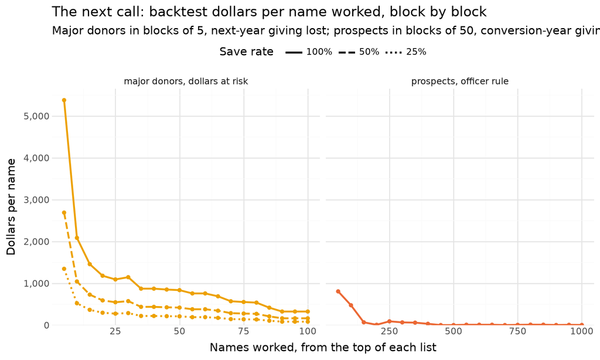

```python
nc = next_call.to_pandas()
(
    ggplot(nc, aes("names_worked", "dollars_per_name", color="list", linetype="save_rate"))
    + geom_line(size=1)
    + geom_point(size=1.3)
    + facet_wrap("list", scales="free_x")
    + scale_color_manual(values={"major donors, dollars at risk": "#eda100", "prospects, officer rule": "#eb6834"}, guide=None)
    + scale_linetype_manual(values={"100%": "solid", "50%": "dashed", "25%": "dotted"})
    + scale_y_continuous(labels=lambda ys: [f"{y:,.0f}" for y in ys], expand=(0, 0, 0.05, 0))
    + labs(x="Names worked, from the top of each list", y="Dollars per name", linetype="Save rate",
           title="The next call: backtest dollars per name worked, block by block",
           subtitle="Major donors in blocks of 5, next-year giving lost; prospects in blocks of 50, conversion-year giving")
    + theme(legend_position="top", figure_size=(8, 4.8))
)
```

```python
assert oc["major donors 1 to 25"] * 0.25 > oc["prospects 1 to 250"]          # the first 25 major donors lead even at a 25% save rate
assert oc["prospects 1 to 250"] > oc["major donors 51 to 100"] * 0.25         # at 25% the first prospects overtake the back of the retention list
assert oc["prospects 251 to 500"] < oc["major donors 51 to 100"] * 0.25       # and the second prospect block falls behind it
assert order_table["names"][0] == "major donors 1 to 25"
"next call claims hold"
```

```
'next call claims hold'
```

- **The first major donors are worth the most per name by a wide margin.** Names 1 to 25 on the dollars-at-risk list carry $2,237 of lost next-year giving per name; names 26 to 50 carry $914 and 51 to 100 carry $524. The first 250 prospects carry $288 of conversion-year giving per name, the next 250 $30, and names 501 to 1,000 $6.
- **The order survives a pessimistic save rate.** If stewardship kept only a quarter of the giving at risk, the first 25 major donors would still be worth $559 per name, ahead of the first 250 prospects at $288. At that rate the first prospects overtake the back of the retention list (names 51 to 100 at $131), and prospects 251 to 500 fall behind it. So the order of work on this release is: the top of the retention list, then the top of the prospect list, then the rest of the retention list, then more prospects, with the exact crossover depending on the save rate.
- **Both lists are short.** All 100 or so major donors fit in the retention list, and the prospect list stops paying for the time to work it somewhere between 250 and 500 names, as the list-size curve showed. The two curves together describe about 600 names a year of worthwhile close work, which is a planning number PBS Utah can set against its staff.

The chart is the method. On PBS Utah’s records the heights will differ, the save rate will come from the holdout test rather than an assumption, and the cost of a name will be known; the question it answers, which call next, stays the same.

### 9.6 The FY2026 Immediate-Priority List

The list covers the 38,219 donors who gave in FY2026 and were not major donors. Under the amendment it is ordered by the officer rule (D23): former major donors first, then FY2026 giving, then years of giving, with the model’s probability breaking any remaining ties. The top 1,000 form the immediate-priority list, and the list-size curve above says the first 500 or so are where the close work belongs. The final 12 month model, trained on FY2021 to FY2025 and scored with the contact flags off, supplies each donor’s probability, the model’s own rank, the expected giving if they convert, and the expected-increase rank, so staff can work from any of the three orderings. The list is person-level, with a flag when a donor’s spouse is also on it, so staff can merge couples themselves (decision D22). Each donor also shows FY2026 giving, former major status, the two inputs that raise that donor’s model score most, and Kate’s two-level indicator as a labeled weak signal. Age, gender, the contact flags, and the FY2021 cohort indicator are left out of the key drivers. Age has no planted effect in this release, and gender describes record completeness more than the donor, as the group EDA found.

```python
LIST_FY = 2026
OUTPUT_DIR = Path("outputs")
OUTPUT_DIR.mkdir(exist_ok=True)
DRIVER_EXCLUDE = {"contacted", "held_out", "age_at_t", "gender_Female", "gender_Male", "gender_Unknown"}

def key_drivers(fitted, df, top=2):
    # the inputs that raise each donor's log-odds most: standardized value times coefficient, ignoring missing indicators
    pipe_ = fitted["estimator"]
    X, cols_ = design(scoring_view(df), fitted["spec"]["features"])
    Z = pipe_[:-1].transform(X)[:, :len(cols_)]
    contrib = Z * pipe_[-1].coef_[0][:len(cols_)]
    keep = np.array([c not in DRIVER_EXCLUDE for c in cols_])
    contrib[:, ~keep] = -np.inf
    order = np.argsort(-contrib, axis=1)[:, :top]
    return [" ; ".join(DRIVER_LABELS[cols_[j]] for j in row if contrib[i, j] > 0) for i, row in enumerate(order)]

p12, score_seconds_2026 = score_with(final_model, frame_2026)
queue_all = (frame_2026.join(p12.rename({"score": "probability_12m"}), on=["constituent_id", "t"])
             # the officer rule (D23) on the same donors; tied donors share the lowest rank of their block
             .with_columns(rule_officer=pl.col("former_major").cast(pl.Float64) * 1e9 + pl.col("prior_total") * 1e4
                           + pl.col("years_ever_given").cast(pl.Float64))
             .with_columns(officer_rule_rank=pl.col("rule_officer").rank("min", descending=True).cast(pl.Int64),
                           probability_rank=pl.col("probability_12m").rank("ordinal", descending=True).cast(pl.Int64))
             # the list is ordered by the officer rule (D23); within a tied block the model's probability breaks the tie
             .sort(["rule_officer", "probability_12m"], descending=[True, True]))
# D25: expected giving from the FY2021 to FY2025 converters' band means, and the expected-increase ordering
queue_all = with_expected(queue_all, 2025, prob="probability_12m").with_columns(
    expected_increase_rank=pl.col("expected_increase").rank("ordinal", descending=True).cast(pl.Int64))
queue = queue_all.head(K).with_columns(rank=pl.int_range(1, K + 1))
on_both_lists = int((queue["probability_rank"] <= K).sum())           # also in the model's top 1,000
on_increase_list = int((queue["expected_increase_rank"] <= K).sum())  # also in the expected-increase top 1,000
tied_at_cutoff = int((queue["officer_rule_rank"] == queue["officer_rule_rank"].max()).sum())

def rule_hits(df):
    # converters in the officer rule's top 1,000 for one cohort, ties at the cutoff split evenly
    (_, y_, w_, gid_), = ranked(df, "rule_officer")
    return float(hits_by_size(y_, w_, gid_, [K])[0])

history_rule = {t: rule_hits(scored.filter(pl.col("t") == t)) for t in (*TEST_COHORTS, 2025)}
# Kate's two-level indicator, fit on every converter from FY1999 to FY2025
two_level_train = converters.filter(pl.col("t").is_between(TIER_START, 2025))
queue = queue.with_columns(
    key_drivers=pl.Series(key_drivers(final_model, queue)),
    chance_of_2000_or_more_if_converts=pl.Series(two_level(two_level_train, queue)),
    spouse_also_on_list=pl.col("couple_id").count().over("couple_id") > 1,
)
expected_2026, low_2026, high_2026 = converter_range(queue["probability_12m"].to_numpy())
# history: converters each backtest list of 1,000 actually held
fy25_top = fy25_df.sort("model_score", descending=True).head(K)
history = {**{r["cohort"]: r["observed_converters"] for r in ranges.iter_rows(named=True)}, 2025: int(fy25_top["y"].sum())}
recent_mix = {name: tm[name]["share_of_test_converters"] for name in TIER_NAMES}
queue_out = queue.select("rank", "probability_rank", "expected_increase_rank", "constituent_id", "spouse_also_on_list", "probability_12m",
                         fy2026_giving="prior_total", expected_giving_if_converts="expected_giving", expected_increase="expected_increase",
                         former_major="former_major", sustainer="sustainer", key_drivers="key_drivers",
                         weak_signal_2000_or_more="chance_of_2000_or_more_if_converts")
queue_out.write_csv(OUTPUT_DIR / "working_queue_FY2026.csv")
# the donors the expected-increase ordering adds, which the probability list leaves off
increase_only = (queue_all.filter((pl.col("expected_increase_rank") <= K) & (pl.col("probability_rank") > K))
                 .sort("expected_increase_rank"))
increase_only.select("expected_increase_rank", "constituent_id", "probability_12m", fy2026_giving="prior_total",
                     expected_giving_if_converts="expected_giving", expected_increase="expected_increase",
                     former_major="former_major").write_csv(OUTPUT_DIR / "working_queue_FY2026_expected_increase_additions.csv")
show(queue_out.head(10), fixed={"probability_12m": 3, "fy2026_giving": 0, "expected_giving_if_converts": 0, "expected_increase": 0, "weak_signal_2000_or_more": 2},
     caption="The first ten donors on the FY2026 immediate-priority list")
```

Table 53: The first ten donors on the FY2026 immediate-priority list

| Rank | Probability rank | Expected increase rank | Constituent id | Spouse also on list | Probability 12m | Fy2026 giving | Expected giving if converts | Expected increase | Former major | Sustainer | Key drivers | Weak signal 2000 or more |
| --- | --- | --- | --- | --- | --- | --- | --- | --- | --- | --- | --- | --- |
| 1 | 17 | 17 | S00006665 | False | 0.150 | 600 | 2,994 | 359 | True | False | FY t giving ; Former major donor | 0.44 |
| 2 | 22 | 22 | S00013450 | False | 0.143 | 600 | 2,994 | 342 | True | False | FY t giving ; Former major donor | 0.46 |
| 3 | 53 | 53 | S00014984 | False | 0.103 | 600 | 2,994 | 246 | True | False | FY t giving ; Former major donor | 0.41 |
| 4 | 2 | 2 | S00025931 | False | 0.281 | 600 | 2,994 | 673 | True | False | FY t giving ; Former major donor | 0.72 |
| 5 | 32 | 32 | S00025937 | False | 0.130 | 600 | 2,994 | 312 | True | False | FY t giving ; Former major donor | 0.42 |
| 6 | 30 | 30 | S00012015 | False | 0.133 | 600 | 2,994 | 319 | True | False | FY t giving ; Former major donor | 0.41 |
| 7 | 50 | 50 | S00034591 | False | 0.107 | 600 | 2,994 | 255 | True | True | FY t giving ; Former major donor | 0.40 |
| 8 | 63 | 63 | S00004028 | False | 0.081 | 600 | 2,994 | 194 | True | False | FY t giving ; Former major donor | 0.37 |
| 9 | 44 | 44 | S00037573 | False | 0.117 | 600 | 2,994 | 279 | True | False | FY t giving ; Former major donor | 0.45 |
| 10 | 6 | 6 | S00012379 | False | 0.164 | 600 | 2,994 | 393 | True | False | FY t giving ; Former major donor | 0.39 |

```python
queue_summary = pl.DataFrame([
    {"measure": "donors on the list", "value": f"{queue.height:,}"},
    {"measure": "former major donors", "value": f"{int(queue['former_major'].sum()):,}"},
    {"measure": "donors whose spouse is also on the list", "value": f"{int(queue['spouse_also_on_list'].sum()):,}"},
    {"measure": "donors also in the model's top 1,000", "value": f"{on_both_lists:,}"},
    {"measure": "donors also in the expected-increase top 1,000 (D25)", "value": f"{on_increase_list:,}"},
    {"measure": "expected converters on this list (model probabilities)", "value": f"{expected_2026:.0f}, 95% range {low_2026:.0f} to {high_2026:.0f}"},
    {"measure": "converters the officer rule's list of 1,000 held in FY2022 to FY2025", "value": ", ".join(f"{history_rule[t]:.0f} (FY{t})" for t in sorted(history_rule))},
    {"measure": "converters the model's list of 1,000 held in FY2022 to FY2025", "value": ", ".join(f"{history[t]} (FY{t})" for t in sorted(history))},
    {"measure": "tier mix of recent converters", "value": " / ".join(f"{100 * recent_mix[n]:.0f}% {n}" for n in TIER_NAMES)},
])
show(queue_summary, caption="FY2026 immediate-priority list at a glance")
```

Table 54: FY2026 immediate-priority list at a glance

| Measure | Value |
| --- | --- |
| donors on the list | 1,000 |
| former major donors | 210 |
| donors whose spouse is also on the list | 0 |
| donors also in the model's top 1,000 | 677 |
| donors also in the expected-increase top 1,000 (D25) | 680 |
| expected converters on this list (model probabilities) | 15, 95% range 8 to 23 |
| converters the officer rule's list of 1,000 held in FY2022 to FY2025 | 41 (FY2022), 29 (FY2023), 39 (FY2024), 66 (FY2025) |
| converters the model's list of 1,000 held in FY2022 to FY2025 | 43 (FY2022), 28 (FY2023), 39 (FY2024), 56 (FY2025) |
| tier mix of recent converters | 59% $1,200 / 38% $2,000 / 3% $5,000+ |

```python
assert queue.height == K and queue["constituent_id"].is_unique().all()
assert high_2026 < min(history.values())               # every past list held more converters than the model's range allows
drivers_top = queue["key_drivers"].value_counts().sort("count", descending=True).row(0, named=True)
"queue claims hold"
```

```
'queue claims hold'
```

- **Who is on it.** 210 of the 1,000 are former major donors. The most common pair of key drivers is “FY t giving ; Largest gift’s share of FY t giving”, for 436 donors. No donor has a spouse also on the list. The rule’s 1,000th place falls inside a block of donors with the same FY2026 giving and years of giving, 4 of whom are on the list by the model’s tie-break. 677 of the 1,000 are also in the model’s top 1,000 and 680 in the expected-increase top 1,000 (D25). The 8 donors the expected-increase ordering would add, whom the model’s own list leaves off, are saved separately as `outputs/working_queue_FY2026_expected_increase_additions.csv`; they gave a median of $48 in FY2026, against $432 for this list. The full list is saved as `outputs/working_queue_FY2026.csv`.
- **How many to expect.** The model’s probabilities for the donors on this list add up to about 15 converters, with a 95% range of 8 to 23. In the backtests, though, the officer rule’s list of 1,000 held 41, 29, 39, 66 converters in FY2022 to FY2025 and the model’s held 43, 28, 39, 56, every year above that range. As the calibration section showed, the probabilities describe donors without officer contact in a typical year. So staff should read the model’s range as a floor and the backtest counts as the more realistic guide (R7).
- **Tier.** If a donor converts, the recent mix is the best guide: 59% at $1,200, 38% at $2,000, 3% at $5,000+. The weak-signal column ranks who is more likely to give $2,000 or more, but with an AUC of 0.63 it should only break ties.

### 9.7 The Long-Term Nurture List

The nurture list holds the next 2,000 donors, outside the immediate-priority list, ranked by the 3 year model (decision D18, with the size to be set with PBS Utah). Each donor is flagged when the 5 year model also places them in its top 2,000 of the same donors. The 3 year model trains on cohorts FY1999 to FY2022, the latest whose 3 year outcome is known, and the 5 year model on FY1999 to FY2020, both on the giving history without soft credits before FY t.

```python
NURTURE_SIZE = 2000
model_3yr = fit_final(2022, spec=LONG_SPECS[SELECTED], grid=None, target="y_3yr")
model_5yr = fit_final(2020, spec=LONG_SPECS[SELECTED], grid=None, target="y_5yr")
assert model_3yr["spec"]["features"] == LONG_FEATURES == model_5yr["spec"]["features"]
p3, _ = score_with(model_3yr, frame_2026)
p5, _ = score_with(model_5yr, frame_2026)
pool = (queue_all.join(p3.rename({"score": "probability_3yr"}), on=["constituent_id", "t"])
        .join(p5.rename({"score": "probability_5yr"}), on=["constituent_id", "t"])
        .filter(~pl.col("constituent_id").is_in(queue["constituent_id"].implode())))
top5 = pool.sort("probability_5yr", descending=True).head(NURTURE_SIZE)["constituent_id"].implode()
nurture = (pool.sort("probability_3yr", descending=True).head(NURTURE_SIZE)
           .with_columns(nurture_rank=pl.int_range(1, NURTURE_SIZE + 1), five_year_model_agrees=pl.col("constituent_id").is_in(top5),
                         spouse_also_on_list=pl.col("couple_id").count().over("couple_id") > 1))
nurture_out = nurture.select("nurture_rank", "constituent_id", "spouse_also_on_list", "probability_3yr", "probability_5yr",
                             "five_year_model_agrees", fy2026_giving="prior_total", former_major="former_major",
                             years_given_last_five="years_last5")
nurture_out.write_csv(OUTPUT_DIR / "nurture_FY2026.csv")
agree_share = float(nurture["five_year_model_agrees"].mean())
nurture_summary = nurture.select(former_major=pl.col("former_major").mean(), median_fy2026_giving=pl.col("prior_total").median(),
                                 five_year_model_agrees=pl.col("five_year_model_agrees").mean(),
                                 mean_probability_3yr=pl.col("probability_3yr").mean())
show(nurture_summary, pct_cols=["former_major", "five_year_model_agrees", "mean_probability_3yr"], fixed={"median_fy2026_giving": 0},
     caption="The FY2026 nurture list of 2,000 donors at a glance")
```

Table 55: The FY2026 nurture list of 2,000 donors at a glance

| Former major | Median fy2026 giving | Five year model agrees | Mean probability 3yr |
| --- | --- | --- | --- |
| 0.0% | 250 | 85.7% | 0.8% |

```python
pool_former = int(frame_2026["former_major"].sum())
assert nurture.height == NURTURE_SIZE and nurture["former_major"].mean() < 0.05
assert int(queue["former_major"].sum()) > pool_former / 2      # most FY2026 former majors are on the immediate list
"nurture claims hold"
```

```
'nurture claims hold'
```

- **Nurture.** The 2,000 nurture donors gave a median of $250 in FY2026, and only 0.0% are former major donors, since 210 of the 210 former majors among FY2026 donors are already on the immediate list. The 5 year model agrees on 86% of them. Given the never-major results in the longer-windows section, the nurture list orders these donors about as well as their giving does, not better, so it is best treated as a list for annual-giving and upgrade appeals. It is saved as `outputs/nurture_FY2026.csv`.

### 9.8 The Retention Risk List

```python
risk_rows = person_years.filter(pl.col("major") & (pl.col("fy") == LIST_FY)).select(
    "constituent_id", "couple_id", t=pl.col("fy").cast(pl.Int32), prior_total="total")
risk_rows = risk_rows.with_columns(former_major=pl.col("constituent_id").is_in(
    major_fys.filter(pl.col("major_fy") < LIST_FY)["constituent_id"].implode()))
risk_rows = build_features(risk_rows, clean, person_years)
retention_model = fit_final(2025, spec=RETENTION_SPEC, grid=None, target="y_drop", data=retention)
pr_, _ = score_with(retention_model, risk_rows)
# the average share of a year's giving that major donors who dropped lost, FY2021 to FY2025
droppers = retention.filter(pl.col("y_drop"))
share_lost = float((droppers["decline"] / droppers["prior_total"]).mean())
risk = (risk_rows.join(pr_.rename({"score": "drop_probability"}), on=["constituent_id", "t"])
        .sort("drop_probability", descending=True)
        .with_columns(risk_rank=pl.int_range(1, pl.len() + 1),
                      dollars_at_risk=pl.col("drop_probability") * share_lost * pl.col("prior_total"),
                      spouse_also_on_list=pl.col("couple_id").count().over("couple_id") > 1,
                      # D24 ordering on the same donors; tied donors share the lowest rank of their block
                      first_time_rule_rank=((pl.col("major_years_before") == 0).cast(pl.Float64) * 1e9 - pl.col("prior_total"))
                      .rank("min", descending=True).cast(pl.Int64),
                      # D27: dollars at risk from the tenure table, FY2021 to FY2025 drop rates, no model needed
                      rule_dollars_at_risk=pl.when(pl.col("major_years_before") == 0).then(tr[True]).otherwise(tr[False]) * share_lost * pl.col("prior_total"))
        .with_columns(dollars_rank=pl.col("dollars_at_risk").rank("ordinal", descending=True).cast(pl.Int64),
                      rule_dollars_rank=pl.col("rule_dollars_at_risk").rank("ordinal", descending=True).cast(pl.Int64)))
risk_out = risk.select("risk_rank", "first_time_rule_rank", "dollars_rank", "rule_dollars_rank", "constituent_id", "spouse_also_on_list", "drop_probability",
                       fy2026_giving="prior_total", rule_dollars_at_risk="rule_dollars_at_risk",
                       dollars_at_risk="dollars_at_risk", earlier_major_years="major_years_before", sustainer="sustainer")
risk_out.write_csv(OUTPUT_DIR / "major_donor_risk_FY2026.csv")
top25_risk = risk.head(25)
show(risk_out.head(10), fixed={"drop_probability": 2, "fy2026_giving": 0, "dollars_at_risk": 0},
     caption="The ten FY2026 major donors most at risk of falling below $1,200 in FY2027")
```

Table 56: The ten FY2026 major donors most at risk of falling below $1,200 in FY2027

| Risk rank | First time rule rank | Dollars rank | Rule dollars rank | Constituent id | Spouse also on list | Drop probability | Fy2026 giving | Rule dollars at risk | Dollars at risk | Earlier major years | Sustainer |
| --- | --- | --- | --- | --- | --- | --- | --- | --- | --- | --- | --- |
| 1 | 3 | 40 | 67 | S00034253 | False | 0.94 | 1,200 | 741.15 | 888 | 0 | False |
| 2 | 3 | 41 | 68 | S00134468 | False | 0.92 | 1,200 | 741.15 | 875 | 0 | True |
| 3 | 44 | 8 | 11 | S00118417 | False | 0.91 | 4,444 | 2,744.74 | 3,212 | 0 | False |
| 4 | 29 | 17 | 17 | S00115466 | False | 0.91 | 2,000 | 1,235.26 | 1,444 | 0 | True |
| 5 | 29 | 18 | 18 | S00043527 | False | 0.91 | 2,000 | 1,235.26 | 1,433 | 0 | True |
| 6 | 3 | 42 | 69 | S00119239 | False | 0.90 | 1,200 | 741.15 | 856 | 0 | True |
| 7 | 3 | 46 | 70 | S00111398 | False | 0.89 | 1,200 | 741.15 | 844 | 0 | True |
| 8 | 1 | 120 | 130 | S00069860 | True | 0.88 | 600 | 370.58 | 416 | 0 | True |
| 9 | 29 | 19 | 19 | S00019487 | False | 0.86 | 2,000 | 1,235.26 | 1,363 | 0 | False |
| 10 | 46 | 7 | 8 | S00010933 | False | 0.85 | 5,000 | 3,088.14 | 3,357 | 0 | False |

```python
assert risk.height == risk_rows.height and (risk.head(10)["major_years_before"] == 0).all()
top25_share = float(top25_risk["dollars_at_risk"].sum() / risk["dollars_at_risk"].sum())
first_time_drop = float(retention.filter(pl.col("major_years_before") == 0)["y_drop"].mean())
repeat_drop = float(retention.filter(pl.col("major_years_before") > 0)["y_drop"].mean())
assert first_time_drop > repeat_drop
"list claims hold"
```

```
'list claims hold'
```

- **Retention risk.** 131 donors were major donors in FY2026. Dollars at risk are each donor’s drop probability times their FY2026 giving times the average share of giving that major donors who dropped lost in FY2021 to FY2025 (79%). Across the list that comes to about $203,686, and the top 25, the capacity R6 tested, holds $80,933 (40%). All ten donors at the top became major donors for the first time in FY2026, which fits the history: 78% of first-time major donors in FY2021 to FY2025 dropped the next year, against 49% of repeat major donors. These are dollars at risk, not dollars an outreach program could recover. The list also carries each donor’s rank under the first-time rule (D24), 14 of the model’s top 25 are in that rule’s top 25, and under dollars at risk from the model and from the tenure table (D27): the two dollar rankings share 23 of their top 25, and those 25 by the table hold $120,445 of the $191,560 at risk by that measure. The list is saved as `outputs/major_donor_risk_FY2026.csv`.

### 9.9 Saved Models

Following Erin’s approach (decision D21), the four FY2026 models are saved with a record of what they were trained on, then reloaded and checked against the scores above. The scoring function always switches the contact flags off, so a saved model cannot score a donor with them on.

```python
import joblib
import sklearn

ARTIFACT_DIR = OUTPUT_DIR / "models"
ARTIFACT_DIR.mkdir(exist_ok=True)
saved = {"prospect_12m": (final_model, "y_12m", frame_2026), "prospect_3yr": (model_3yr, "y_3yr", frame_2026),
         "prospect_5yr": (model_5yr, "y_5yr", frame_2026), "retention": (retention_model, "y_drop", risk_rows)}
artifact_rows = []
for name, (fitted, target, donors) in saved.items():
    path = ARTIFACT_DIR / f"{name}.joblib"
    joblib.dump({"estimator": fitted["estimator"], "features": fitted["spec"]["features"], "columns": fitted["columns"]}, path)
    meta = {"model": name, "target": target, "train_start": fitted["spec"]["train_start"], "train_end": fitted["train_end"],
            "training_rows": fitted["training_rows"], "features": fitted["spec"]["features"],
            "scoring": "contact flags switched off (scoring_view)", "sklearn": sklearn.__version__, "polars": pl.__version__,
            "sha256": hashlib.sha256(path.read_bytes()).hexdigest()}
    (ARTIFACT_DIR / f"{name}.json").write_text(json.dumps(meta, indent=2))
    # reload and rescore: the saved model must give the same probabilities
    loaded = joblib.load(path)
    assert hashlib.sha256(path.read_bytes()).hexdigest() == meta["sha256"]
    X_reload, _ = design(scoring_view(donors), loaded["features"])
    fresh_scores, _ = score_with(fitted, donors)
    reload_diff = float(np.abs(predict_score(loaded["estimator"], X_reload) - fresh_scores["score"].to_numpy()).max())
    assert reload_diff == 0.0
    artifact_rows.append({"model": name, "outcome": target, "training_cohorts": f"FY{meta['train_start']} to FY{meta['train_end']}",
                          "training_rows": meta["training_rows"], "inputs": len(meta["features"]), "max_reload_difference": reload_diff,
                          "sha256": meta["sha256"][:12]})
artifacts = pl.DataFrame(artifact_rows)
assert (artifacts["max_reload_difference"] == 0).all()
show(artifacts, caption="Saved FY2026 models: training data, inputs, and the reload check (identical scores)")
```

Table 57: Saved FY2026 models: training data, inputs, and the reload check (identical scores)

| Model | Outcome | Training cohorts | Training rows | Inputs | Max reload difference | Sha256 |
| --- | --- | --- | --- | --- | --- | --- |
| prospect_12m | y_12m | FY2021 to FY2025 | 160,919 | 15 | 0.00 | a7df69c994de |
| prospect_3yr | y_3yr | FY1999 to FY2022 | 433,003 | 14 | 0.00 | e77373500ef1 |
| prospect_5yr | y_5yr | FY1999 to FY2020 | 370,962 | 14 | 0.00 | b687ba4afdd4 |
| retention | y_drop | FY2021 to FY2025 | 503 | 13 | 0.00 | 3d6dc931d8c1 |

### 9.10 Coverage Audit

Kate’s notebook checked whether the list looks like the donors it is drawn from and the donors who have converted before. Age, gender, and state are not presented as drivers, but the list should still be checked for gaps before staff use it.

```python
def age_band(col="age_at_t"):
    return (pl.when(pl.col(col) < 40).then(pl.lit("under 40")).when(pl.col(col) < 60).then(pl.lit("40 to 59"))
            .when(pl.col(col) < 75).then(pl.lit("60 to 74")).otherwise(pl.lit("75 and over")))

past_conv = frame.filter(pl.col("t").is_between(2021, 2025) & pl.col("y_12m"))
groups_ = {"FY2026 list": queue, "FY2026 eligible donors": frame_2026, "FY2021 to FY2025 converters": past_conv}
cov_rows = []
for dim, expr in (("age", age_band()), ("gender", pl.col("gender")), ("lives in Utah", pl.col("lives_in_utah").cast(pl.String))):
    for g, df in groups_.items():
        shares = df.select(level=expr).group_by("level").len().with_columns(share=pl.col("len") / pl.col("len").sum())
        for r in shares.iter_rows(named=True):
            cov_rows.append({"dimension": dim, "level": r["level"], "group": g, "share": r["share"]})
coverage = pl.DataFrame(cov_rows).pivot(on="group", index=["dimension", "level"], values="share").sort("dimension", "level")
cv = {(r["dimension"], r["level"]): r for r in coverage.iter_rows(named=True)}
show(coverage, pct_cols=list(groups_), caption="Coverage audit: the FY2026 list, the eligible donors, and past converters by age, gender, and state")
```

Table 58: Coverage audit: the FY2026 list, the eligible donors, and past converters by age, gender, and state

| Dimension | Level | FY2026 list | FY2026 eligible donors | FY2021 to FY2025 converters |
| --- | --- | --- | --- | --- |
| age | 40 to 59 | 22.2% | 25.8% | 24.8% |
| age | 60 to 74 | 25.0% | 24.9% | 25.2% |
| age | 75 and over | 42.8% | 34.4% | 45.6% |
| age | under 40 | 10.0% | 14.8% | 4.4% |
| gender | Female | 38.7% | 31.8% | 49.6% |
| gender | Male | 27.9% | 23.3% | 37.0% |
| gender | Unknown | 33.4% | 44.9% | 13.3% |
| lives in Utah | false | 16.1% | 16.0% | 20.0% |
| lives in Utah | true | 83.9% | 84.0% | 80.0% |

```python
old_list, old_conv, old_pool = (cv[("age", "75 and over")][g] for g in ("FY2026 list", "FY2021 to FY2025 converters", "FY2026 eligible donors"))
unk = {g: cv[("gender", "Unknown")][g] for g in groups_}
assert old_list > old_pool and abs(old_list - old_conv) < abs(old_list - old_pool)
assert unk["FY2026 list"] < unk["FY2026 eligible donors"] and unk["FY2026 list"] > unk["FY2021 to FY2025 converters"]
tenure = frame_2026.with_columns(band=age_band()).group_by("band").agg(pl.col("years_since_first_gift").mean())
tenure = dict(tenure.iter_rows())
assert tenure["75 and over"] > tenure["40 to 59"] > tenure["under 40"]
"coverage claims hold"
```

```
'coverage claims hold'
```

- **The list looks like past converters more than like the eligible pool.** Donors 75 and over are 43% of the list, against 34% of eligible donors and 46% of past converters. Age has no planted effect in this release, so this most likely comes through giving history: FY2026 donors 75 and over first gave 12 years earlier on average, against 4 for donors under 40.
- **Unknown gender.** Donors with gender recorded as Unknown are 33% of the list, against 45% of eligible donors and 13% of past converters. Kate found the same gap in her notebook. Unknown gender reflects how complete a record is, so some donors on the list may have thin records. That is worth checking before rollout, and it is not a reason to add gender to the model.
- **State.** The list’s share of Utah residents (84%) is close to both the pool and past converters.

## 10 Results

### 10.1 Summary of Results

```python
def result_row(question, cohorts, compared, model_value, bar_value, gain, low, high, decision):
    # one line of the summary; values are shares, gains are in percentage points
    return {"question": question, "cohorts": cohorts, "compared_with": compared, "model": model_value, "benchmark": bar_value,
            "gain": gain, "gain_low": low, "gain_high": high, "outcome": decision}

def pts(d):
    return 100 * d["gain"], 100 * d["low"], 100 * d["high"]

never_sel = cs[("never major", SELECTED)]["recall"]
summary_rows = [
    result_row("12 months, all eligible", "FY2022 to FY2024", "prior-year giving", sel_all["recall"], ba["prior-year giving"]["recall"],
               *pts(gain_all[first]), "selected under R1"),
    result_row("12 months, all eligible", "FY2022 to FY2024", "former major or $500", sel_all["recall"],
               ba["former major or $500"]["recall"], *pts(vs_rule[first]), "clears the second check"),
    result_row("12 months, never major", "FY2022 to FY2024", "prior-year giving", never_sel, bn["prior-year giving"]["recall"],
               *pts(cd[("never major", first, "prior-year giving")]), "no measurable gain"),
    result_row("12 months, all eligible", "FY2022 to FY2024", "officer rule (D23)", main_vs_officer["model"],
               main_vs_officer["officer_rule"], main_vs_officer["gain"], main_vs_officer["gain_low"], main_vs_officer["gain_high"],
               "model wins (amendment)" if officer_wins[("rolling test", "all eligible")] else "no measurable gain (amendment)"),
    result_row("12 months, before the program", "FY2018 to FY2021", "officer rule (D23)", pre_vs_officer["model"],
               pre_vs_officer["officer_rule"], pre_vs_officer["gain"], pre_vs_officer["gain_low"], pre_vs_officer["gain_high"],
               "report only (R3, amendment)"),
    result_row("conversion-year dollars at 1,000, expected increase (D25)", "FY2022 to FY2024", "model probability",
               dol_inc["share_on_list"], prob_dollars["share_on_list"], dol_inc["gain_vs_probability"], dol_inc["gain_low"], dol_inc["gain_high"],
               "no measurable difference (amendment)"),
    result_row("increase over prior year at 1,000, expected increase (D25)", "FY2022 to FY2024", "model probability",
               rise_inc["share_on_list"], ex[("increase over the prior year", "model probability")]["share_on_list"],
               rise_inc["gain_vs_probability"], rise_inc["gain_low"], rise_inc["gain_high"], "no measurable difference (amendment)"),
    result_row("12 months, held-back cohort", "FY2025", "prior-year giving", fy25c["recall"], fy25c["prior_year_recall"],
               fy25c["gain"], fy25c["gain_low"], fy25c["gain_high"], "report only (R3)"),
    result_row("12 months, before the program", "FY2018 to FY2021", "prior-year giving", prec["recall"], prec["prior_year_recall"],
               prec["gain"], prec["gain_low"], prec["gain_high"], "report only (R3)"),
    result_row("within 3 years", "FY2021 to FY2022", "prior-year giving", g3["recall"], lt[(L3, "all eligible", "prior-year giving")]["recall"],
               g3["gain"], g3["gain_low"], g3["gain_high"], "selected family kept (R4)"),
    result_row("within 5 years", "FY2016 to FY2020", "prior-year giving", g5["recall"], lt[(L5, "all eligible", "prior-year giving")]["recall"],
               g5["gain"], g5["gain_low"], g5["gain_high"], "selected family kept (R4)"),
    result_row("giving tier, exact", "FY2022 to FY2024", "most-common-tier rule", multi["exact_accuracy"], rule["exact_accuracy"],
               tier_gain["gain"], tier_gain["low"], tier_gain["high"], "rule stands (R5)"),
    result_row("retention, top 25 a year", "FY2022 to FY2024", "lowest giving first", m25["share_of_droppers"], l25["share_of_droppers"],
               *pts(r25), "recommended (R6)"),
    result_row("retention, top 25 a year", "FY2022 to FY2024", "first-time majors first (D24)", m25["share_of_droppers"],
               f25["share_of_droppers"], *pts(r25_rule), "model wins (amendment)" if MODEL_BEATS_RULE else "no measurable gain (amendment)"),
]
summary_table = pl.DataFrame(summary_rows)
# claims in the Results text
assert prec["gain"] / 100 < gain_all[first]["gain"] and prec["never_major_gain_low"] > 0
assert all(cd[("never major", t, "prior-year giving")]["high"] < 0 for t in ("LightGBM", "histogram gradient boosting"))
assert not r2_replaces and SELECTED == first and TIER_CHOICE == "most-common-tier rule" and RETENTION_RECOMMENDED
assert final_model["fit_seconds"] < 1
show(summary_table, pct_cols=["model", "benchmark"], fixed={"gain": 1, "gain_low": 1, "gain_high": 1},
     caption="Summary of results: recall at 1,000 (tier: exact accuracy; retention: share of droppers in the top 25), with paired gains in points")
```

Table 59: Summary of results: recall at 1,000 (tier: exact accuracy; retention: share of droppers in the top 25), with paired gains in points

| Question | Cohorts | Compared with | Model | Benchmark | Gain | Gain low | Gain high | Outcome |
| --- | --- | --- | --- | --- | --- | --- | --- | --- |
| 12 months, all eligible | FY2022 to FY2024 | prior-year giving | 82.1% | 75.4% | 6.7 | 2.2 | 11.4 | selected under R1 |
| 12 months, all eligible | FY2022 to FY2024 | former major or $500 | 82.1% | 76.6% | 5.5 | 1.8 | 9.7 | clears the second check |
| 12 months, never major | FY2022 to FY2024 | prior-year giving | 61.0% | 59.6% | 1.4 | -7.4 | 9.0 | no measurable gain |
| 12 months, all eligible | FY2022 to FY2024 | officer rule (D23) | 82.1% | 81.6% | 0.5 | -4.3 | 5.1 | no measurable gain (amendment) |
| 12 months, before the program | FY2018 to FY2021 | officer rule (D23) | 86.8% | 85.4% | 1.4 | -1.7 | 3.5 | report only (R3, amendment) |
| conversion-year dollars at 1,000, expected increase (D25) | FY2022 to FY2024 | model probability | 86.2% | 86.9% | -0.7 | -2.2 | 0.0 | no measurable difference (amendment) |
| increase over prior year at 1,000, expected increase (D25) | FY2022 to FY2024 | model probability | 83.9% | 84.7% | -0.9 | -2.8 | 0.0 | no measurable difference (amendment) |
| 12 months, held-back cohort | FY2025 | prior-year giving | 69.1% | 69.2% | 0.0 | -7.0 | 8.4 | report only (R3) |
| 12 months, before the program | FY2018 to FY2021 | prior-year giving | 86.8% | 82.5% | 4.3 | 1.7 | 6.1 | report only (R3) |
| within 3 years | FY2021 to FY2022 | prior-year giving | 68.2% | 58.8% | 9.4 | 4.8 | 13.7 | selected family kept (R4) |
| within 5 years | FY2016 to FY2020 | prior-year giving | 62.0% | 58.4% | 3.6 | 0.8 | 6.2 | selected family kept (R4) |
| giving tier, exact | FY2022 to FY2024 | most-common-tier rule | 57.5% | 59.0% | -1.5 | -3.8 | 0.0 | rule stands (R5) |
| retention, top 25 a year | FY2022 to FY2024 | lowest giving first | 32.0% | 28.5% | 3.5 | 0.1 | 8.9 | recommended (R6) |
| retention, top 25 a year | FY2022 to FY2024 | first-time majors first (D24) | 32.0% | 34.7% | -2.7 | -4.9 | 1.3 | no measurable gain (amendment) |

What PBS Utah takes from this notebook is a procedure, and the summary table is one run of it on a synthetic copy of its records. The procedure has five steps, and each produced a result here that is an example of what the step can show, not a fact about PBS Utah’s donors.

1. **Write down the best list an officer could build by hand, then ask whether a model beats it.** Against the sort PBS Utah uses today, last year’s giving, the selected model found 6.7 points more of next year’s major donors at a list of 1,000 (82.1% against 75.4%), and the simplest of our four logistic regressions did it as well as any. Against the officer rule added under D23, former major donors first and then last year’s giving with ties broken by years of giving, it did not: 82.1% against 81.6% (0.5 points, -4.3 to 5.1), with the rule ahead by 12.3 points in the FY2026 influx year. The whole gain over today’s sort comes from putting former major donors first and ordering the block of donors tied at $250, and a rule does both. Which bar a model is held to decides what it appears to add.
2. **Rank by expected dollars, and check whether it changes anything.** Probability times the expected giving of past converters in the same band reordered a few names and no measurable dollars (D25), because the model’s probability varies thirty-fold across giving bands and the expected amount hardly varies at all. The list carries both orderings so the same test can be run where the dollar level is more predictable.
3. **Read the list size off the curve.** The first 250 names by either ranking hold 85% of the converters and 89% of the dollars that 1,000 names hold; names 501 to 1,000 add about 2 converters a year; by 2,000 the ranking no longer matters (D26). The 1,000 we started from came from invented tables; the curve says about 500.
4. **Do the same for retention.** The first-time rule (D24) found as many droppers in the top 25 as the model and cleared the R6 bar more clearly. Dollars at risk from a two-number tenure table covered about twice the lost giving of any donor-count ranking and tied the model’s version (D27). Neither stewardship list needs the model.
5. **Put both lists in dollars per name and order the work.** The first 25 at-risk major donors carried $2,237 of lost next-year giving per name and the first 250 prospects $288 of conversion-year giving per name (D28), an order that holds even at a 25% save rate.

On this release, every job we gave a model was done as well by a rule a development officer could apply in a spreadsheet. We do not know whether that will hold on PBS Utah’s records, and that is the point: the procedure above is how PBS Utah finds out, and the numbers here show what each step looks like when it is run.

### 10.2 What the Modeling Process Showed

- **Rules written before the results decided which models were kept.** R1 compared four logistic regressions and kept Erin’s untuned one, because none of the others beat it by a measurable margin. Tuning chose very different penalties from one year to the next, a sign that 55 to 145 training converters cannot pin a penalty down. R2 kept the use list, R4 the selected family, R5 the most-common-tier rule, and R6 recommended the retention model by a narrow margin.
- **The bar matters as much as the model.** Against prior-year giving, the sort PBS Utah uses today, every logistic regression won. Against the officer rule added afterwards (D23), none did, and the rule was better in the influx year. Which bar a model is held to decides what it appears to add, so the first step on real data is to write down the best unaided list before fitting anything.
- **More flexible models did not help.** Random forests, LightGBM, histogram gradient boosting, and an explainable boosting machine all did worse than or no better than the logistic regression, and two of them were measurably worse than the prior-year ranking for never-major donors.
- **Engagement adds nothing measurable.** With every input, including solicitations and Passport viewing, the selected model did not improve (R2). That answers the revised business problem’s question about engagement for this release.
- **Calibration needs a caveat.** Pooled over the test cohorts the predicted total of converters is close to the observed total, but the probabilities ran well below what happened in FY2024 and FY2025, when simulated contact and the FY2026 influx pushed conversion up.
- **One input had to be handled by era.** Soft credits before FY t exist only from FY2021, which distorted models trained from FY1999. We found this from the tier model’s predicted mix, dropped the input from those models only, and showed both versions in the Giving Tier subsection.

### 10.3 Can the Results Solve the Business Problem?

As a method, yes; as a set of numbers, no, because the numbers are synthetic. The revised business problem asks for a ranked list of likely major donors for the next 12 months and the next 3 to 5 years, the likely giving tier, and current major donors at risk of dropping. Here is what the procedure produced for each request on this release, and what PBS Utah would do with the same step on its own records:

- **The 12 month list: the officer rule, with the model alongside it.** Both beat today’s sort on the test cohorts by about 3 converters a year, and they cannot be told apart from each other. Under the amendment the rule is the list, because it is the simpler option and it held up in the influx year when the model did not. The model still supplies what a rule cannot: a probability for each donor, which gives staff the expected-converter range and a way to rank by expected giving.
- **The list size is an output, and on this release it is about 500, not 1,000.** The first 250 names by either ranking hold 85% of what 1,000 hold, names 501 to 1,000 add about 2 converters a year, and by 2,000 names the ranking no longer matters (D26). PBS Utah should set the size from the same curve on its own records, where the cost of the next 250 names is known.
- **The 3 to 5 year scores rank all eligible donors better than last year’s giving.** For never-major donors they do no better, so the nurture list is best used for annual-giving and upgrade appeals.
- **The tier cannot be predicted.** A recent mix of 59% / 38% / 3% is what staff should plan around. For the same reason, ranking by expected giving instead of probability (D25) changes the list by a few names and the dollars by nothing measurable on this release; the list carries both so the method is in place for real data.
- **Retention: two rules, and no job left for the model.** To keep the most donors above $1,200, the first-time rule (D24) finds as many droppers in the top 25 as the model and clears the R6 bar more clearly. To keep the most dollars, dollars at risk from a two-number tenure table covers about twice the lost giving of any donor-count ranking and ties the model’s version (D27). Which to work is PBS Utah’s choice about what stewardship is for; neither needs the model.
- **The next call.** In backtest dollars per name worked, the first 25 at-risk major donors carry $2,237 each and the first 250 prospects $288 each (D28). Even if stewardship kept only a quarter of the giving at risk, the order of work would be the top of the retention list first, then the top of the prospect list, about 600 names a year of worthwhile close work between them.

The business problem’s larger aim, more major donors and more major-gift revenue, will not be met by ranking alone. On this release the donors who were already major gave about as much less each year as new major donors added, and the gain from a better prospect list was a few converters a year. What the work delivers is the procedure: the rules, the tests, the curves, and the code that runs them, which PBS Utah can point at its own records to learn where its staff’s time is worth most.

### 10.4 Risks and Limitations

- **Synthetic data and simulated contact.** The release replicates PBS Utah’s data, and the cultivation tables were invented. In the test cohorts 81% of converters had been selected for cultivation, and simulated contact shaped who converted. The cleanest test, before the program, shows a gain of 4.3 points, smaller than the main test’s.
- **The FY2026 influx.** On the FY2025 cohort, whose outcomes fall in FY2026, the model’s edge over prior-year giving disappeared, while the officer rule kept its 81.5%. A model trained on FY2021 to FY2024 had not seen a year like FY2026, and a rule has nothing to learn. If conditions keep changing, the model may do no better than a dollar sort in a given year.
- **Small numbers.** The main test rests on 134 converters, 59 of them never-major, and retention on about 100 major donors a year. Several intervals are wide, and a few converters can move a result.
- **Probabilities as forecasts.** The probabilities order donors well but understate how many will convert when contact or new donors raise conversion. The backtest counts are the better guide to how many converters a list of 1,000 holds.
- **Longer windows rest on the legacy years.** The 3 and 5 year models train mostly on cohorts recorded in the older gift system, and they use giving history only.
- **Record quality.** Donors with unknown gender are overrepresented on the list relative to past converters, which may mean thin records. Age has no planted effect in this release, so its place in the model should be retested on real data.

### 10.5 Recommendations: Tests for PBS Utah

Because the results come from a synthetic release, every recommendation is a test PBS Utah can run on its own records (decision D14). The order below is the order of the procedure:

1. **Rerun the notebook on PBS Utah’s own records.** Use the same validation code and the same rules, written before the results, with the officer rule (D23) as a bar from the start this time. Report the gain over prior-year giving and over the rule, overall, for never-major donors, and before and after the cultivation program. If the model does not beat the rule on real data either, use the rule for the list and the model for the probabilities.
2. **Keep a random holdout in cultivation and record every contact.** The program already holds out some selected donors. Recording which donors were contacted, and how, would let PBS Utah measure what cultivation adds and compare the model’s list with officers’ choices on real data.
3. **Test stewardship on the retention list.** Decide whether the goal is donors kept or dollars kept, work the top 25 by the matching rule each year (first-time major donors first, or dollars at risk from the tenure table), hold out a random comparison group, and record the touchpoints. Retention is worth about as much as conversion, and this is the only way to learn which touchpoints keep donors at $1,200 or more.
4. **Rescore every year after June 30 with the saved models, and redraw the list-size curve.** Check calibration each year, show staff the backtest counts alongside the model’s range of expected converters, and set the list size where the next 250 names stop paying for the time to work them.
5. **Order officer time from the two curves.** Redraw the prospect and retention curves in dollars per name each year, put the save rate from the holdout test on the retention side, and work the blocks in order of return until the next block no longer pays for the time.
6. **Retest the closest alternatives on real data.** Kate’s log-dollar and giving-band variant had the best inner average precision and the largest never-major point gain. The FY2014 training window also scored slightly higher. Neither cleared our rules here, but either could on a larger, real dataset.

## 11 Appendix

### 11.1 Checks on Numbers in the Introduction

The introduction comes before any code runs, so its numbers are written as text. This chunk recomputes them and stops the render if any no longer holds. Numbers later in the notebook are computed inline.

```python
active12 = cohorts.filter((pl.col("segment") == "active") & (pl.col("window") == 1))
test12 = active12.filter(pl.col("t").is_between(2022, 2024))
sizes = test12.group_by("t").len()["len"]

# share of donors and of individual giving that is major, FY2021 to FY2026, couples counted once (group EDA method)
share = (
    person_years.filter(pl.col("fy") >= 2021).group_by("fy")
    .agg(donors=pl.len(), major_donors=pl.col("couple_id").filter(pl.col("major")).n_unique(),
         revenue=pl.col("total").sum(), major_revenue=pl.col("total").filter(pl.col("major")).sum())
    .select(donors=pl.col("major_donors").sum() / pl.col("donors").sum(),
            revenue=pl.col("major_revenue").sum() / pl.col("revenue").sum())
    .row(0, named=True)
)
# major donors in FY2021 to FY2025 who were not major the following year
next_major = person_years.select("constituent_id", fy=pl.col("fy") - 1, next_major="major")
majors_t = (person_years.filter(pl.col("major") & pl.col("fy").is_between(2021, 2025))
            .join(next_major, on=["constituent_id", "fy"], how="left")
            .with_columns(pl.col("next_major").fill_null(False)))

intro_claims = {
    "major donors are about 0.3% of donors": round(100 * share["donors"], 1) == 0.3,
    "major donors give about 8% of individual giving": round(100 * share["revenue"]) == 8,
    "about 57% of major donors fall below $1,200 the next year": round(100 * (1 - majors_t["next_major"].mean())) == 57,
    "test cohorts hold about 31,000 to 33,000 eligible donors each": round(sizes.min(), -3) == 31_000 and round(sizes.max(), -3) == 33_000,
    "134 converters in the test cohorts": test12["converted"].sum() == 134,
    "59 of them never-major": (test12["converted"] & ~test12["former_major"]).sum() == 59,
    "predicting no for everyone is more than 99.8% accurate": 1 - test12["converted"].mean() > 0.998,
}
failed = [claim for claim, ok in intro_claims.items() if not ok]
assert not failed, failed
# the 75.4% and 59.6% bars are reproduced and asserted in the Benchmarks section
f"{len(intro_claims)} introduction checks passed"
```

```
'7 introduction checks passed'
```

### 11.2 Use of AI Tools

```python
source_lines = Path("pbs_utah_group_modeling.qmd").read_text(encoding="utf-8").splitlines()
n_asserts = sum(line.strip().startswith("assert ") for line in source_lines)
n_claim_chunks = sum(line.strip().startswith("#| label:") and "claims" in line for line in source_lines)
```

All four of us used AI assistants in our individual modeling notebooks, which this notebook draws on. This group notebook was built with Claude Code (Anthropic), which drafted the analysis code, the tables and plots, and first drafts of the prose. The team set every definition and decision, including the 22 agreed decisions and the seven rules written before the results, and each step was reviewed before the next one was written. Two choices during the work were put to the team rather than made by the assistant: how to present the expected number of converters, and how to handle the soft-credit input by era.

AI output was not accepted on trust. It was checked in these ways:

- **Reproducing the agreed numbers.** The scoring code reproduces every baseline the group EDA published, to the decimal, and the validation code reproduces the prior-year bar exactly with three check models.
- **Assertions.** The notebook contains 157 assertions, including 22 chunks that test the claims made in words, such as “beats”, “no measurable gain”, “most”, and “the same”, against the numbers. The render stops if any fails.
- **Leakage and window checks.** Rebuilding three cohorts from data cut at June 30 gives identical features, and the rolling windows are asserted to end before each test cohort.
- **Reading the output.** Every table, plot, and sentence was read against the rendered numbers before a step was accepted. Several drafted sentences were corrected this way, for example one that called predicted and observed converters close below the top of the list when they were not, and one that called an interval including 0.5 “below chance”. Reading the tier model’s predicted mix is also how the soft-credit problem was found.

### 11.3 Team Contributions

This notebook was an even group effort. All four of us completed an individual modeling notebook, compared them together, and agreed on the decisions and rules in the introduction. The pieces each individual notebook contributed are credited in the Purpose section and where they are used: Erin’s untuned logistic regression, list composition, and saved model; Benjamin’s validation code, pre-set rules, release-note checks, longer windows, and tier comparison; Kate’s log-dollar and band variant, 3-year total benchmark, converters found by one list, two-level tier indicator, and coverage audit; and Samantha’s ridge regression, retention workflow, and retention evaluation at officer capacity.

### 11.4 Reproducing This Notebook

```python
import importlib.metadata as md
import platform

environment = pl.DataFrame([{"package": "python", "version": platform.python_version()}] + [
    {"package": pkg, "version": md.version(pkg)}
    for pkg in ("polars", "pandas", "numpy", "scikit-learn", "lightgbm", "interpret", "scipy", "plotnine", "joblib")
])
show(environment, caption="Software versions used to render this notebook")
```

Table 60: Software versions used to render this notebook

| Package | Version |
| --- | --- |
| python | 3.13.16 |
| polars | 1.38.1 |
| pandas | 2.3.3 |
| numpy | 2.5.4 |
| scikit-learn | 1.9.1 |
| lightgbm | 4.7.0 |
| interpret | 0.7.8 |
| scipy | 1.18.1 |
| plotnine | 0.15.8 |
| joblib | 1.6.0 |

- **Data.** The notebook reads the course tables from the Parquet cache in `../data_cache`, which is committed with the group EDA, and builds every table with the group’s `build_panel.py`. The raw CSV files in `../../tables` are needed only to rebuild that cache.
- **Saved fits.** Model fits are saved to `model_cache/` under a key built from everything that defines each run, so later renders read them back. The folder is committed, so a render on another machine with the same package versions reads the saved fits and takes 6 to 10 minutes. Setting `RERUN = True` in the validation code refits everything. A full render from an empty cache took about 50 minutes on a 16 GB laptop, most of it tuning the challengers and fitting the explainable boosting machine, which is limited to two worker processes to stay within memory. Render with `quarto render pbs_utah_group_modeling.qmd --no-execute-daemon`, because a kernel left running by an earlier render can hold several gigabytes and starve those workers.
- **Outputs.** The FY2026 lists and the saved models are written to `outputs/`, which is committed so the lists can be opened without rendering. Each render rewrites them.
- **Seeds.** Every bootstrap uses the group EDA’s seed, and every model with randomness uses the same seed. A render from an empty cache and a render from saved fits gave identical results; only the run times differ.